# Unknown perpetrator shootings analysis

Michele Lotto

2024-01-19

# 1 Requirements

```r
requirements=c("summarytools", "pROC", "glmnetUtils", "dplyr", "car", "effects", "gridExtra", "grid", "MASS","e1071", "mgcv")

for (req in requirements){
  if (!require(req, character.only = TRUE)){
      install.packages(req)
  }
}
```

# 2 Loading data

```r
shootings <- readRDS("data/shootings_unknown.Rda")
print(dfSummary(shootings), method="render")
```

| **No** | **Variable** | **Stats / Values** | **Freqs (% of Valid)** | **Graph** | **Valid** | **Missing** |
| --- | --- | --- | --- | --- | --- | --- |
| 1 | day_period [factor] | 1. EarlyMorning 2. Morning 3. EarlyAfternoon 4. Afternoon 5. Evening 6. Night | 611 ( 5.4% ) 430 ( 3.8% ) 691 ( 6.1% ) 1709 ( 15.0% ) 2516 ( 22.1% ) 5410 ( 47.6% ) |  | 11367 (100.0%) | 0 (0.0%) |
| 2 | day_year [numeric] | Mean (sd) : 199.6 (93.6) min ≤ med ≤ max: 1 ≤ 203 ≤ 366 IQR (CV) : 133 (0.5) | 366 distinct values |  | 11367 (100.0%) | 0 (0.0%) |
| 3 | year [numeric] | Mean (sd) : 2014.3 (4.8) min ≤ med ≤ max: 2006 ≤ 2014 ≤ 2022 IQR (CV) : 9 (0) | 17 distinct values |  | 11367 (100.0%) | 0 (0.0%) |
| 4 | week_day [factor] | 1. Monday 2. Tuesday 3. Wednesday 4. Thursday 5. Friday 6. Saturday 7. Sunday | 1691 ( 14.9% ) 1217 ( 10.7% ) 1138 ( 10.0% ) 1211 ( 10.7% ) 1448 ( 12.7% ) 2209 ( 19.4% ) 2453 ( 21.6% ) |  | 11367 (100.0%) | 0 (0.0%) |
| 5 | COVID_lockdown [factor] | 1. FALSE 2. TRUE | 10608 ( 93.3% ) 759 ( 6.7% ) |  | 11367 (100.0%) | 0 (0.0%) |
| 6 | COVID_pandemic [factor] | 1. FALSE 2. TRUE | 8671 ( 76.3% ) 2696 ( 23.7% ) |  | 11367 (100.0%) | 0 (0.0%) |
| 7 | working_hour [factor] | 1. FALSE 2. TRUE | 10083 ( 88.7% ) 1284 ( 11.3% ) |  | 11367 (100.0%) | 0 (0.0%) |
| 8 | Latitude [numeric] | Mean (sd) : 40.7 (0.1) min ≤ med ≤ max: 40.5 ≤ 40.7 ≤ 40.9 IQR (CV) : 0.2 (0) | 6993 distinct values |  | 11367 (100.0%) | 0 (0.0%) |
| 9 | Longitude [numeric] | Mean (sd) : -73.9 (0.1) min ≤ med ≤ max: -74.2 ≤ -73.9 ≤ -73.7 IQR (CV) : 0.1 (0) | 6985 distinct values |  | 11367 (100.0%) | 0 (0.0%) |
| 10 | city_location [factor] | 1. S_Manhattan 2. N_Manhattan 3. W_Bronx 4. E_Bronx 5. N_E_Queens 6. N_W_Queens 7. S_Queens 8. N_Brooklyn 9. S_E_Brooklyn 10. S_W_Brooklyn [ 2 others ] | 123 ( 1.1% ) 1153 ( 10.1% ) 2181 ( 19.2% ) 885 ( 7.8% ) 355 ( 3.1% ) 338 ( 3.0% ) 992 ( 8.7% ) 2241 ( 19.7% ) 2471 ( 21.7% ) 446 ( 3.9% ) 182 ( 1.6% ) |  | 11367 (100.0%) | 0 (0.0%) |
| 11 | vic_age [factor] | 1. <18 2. 18-24 3. 25-44 4. 45+ | 1073 ( 9.4% ) 4357 ( 38.3% ) 5200 ( 45.7% ) 737 ( 6.5% ) |  | 11367 (100.0%) | 0 (0.0%) |
| 12 | vic_sex [factor] | 1. F 2. M | 872 ( 7.7% ) 10495 ( 92.3% ) |  | 11367 (100.0%) | 0 (0.0%) |
| 13 | vic_race [factor] | 1. ASIAN/WHITE 2. BLACK 3. BLACK HISPANIC 4. WHITE HISPANIC | 304 ( 2.7% ) 8723 ( 76.7% ) 1013 ( 8.9% ) 1327 ( 11.7% ) |  | 11367 (100.0%) | 0 (0.0%) |
| 14 | other_victims [numeric] | Mean (sd) : 0.4 (1) min ≤ med ≤ max: 0 ≤ 0 ≤ 9 IQR (CV) : 0 (2.4) | 0 : 8930 ( 78.6% ) 1 : 1428 ( 12.6% ) 2 : 194 ( 1.7% ) 3 : 619 ( 5.4% ) 4 : 5 ( 0.0% ) 5 : 150 ( 1.3% ) 6 : 7 ( 0.1% ) 7 : 24 ( 0.2% ) 9 : 10 ( 0.1% ) |  | 11367 (100.0%) | 0 (0.0%) |
| 15 | jurisdiction [factor] | 1. PATROL 2. HOUSING | 9383 ( 82.5% ) 1984 ( 17.5% ) |  | 11367 (100.0%) | 0 (0.0%) |
| 16 | murder [factor] | 1. FALSE 2. TRUE | 9481 ( 83.4% ) 1886 ( 16.6% ) |  | 11367 (100.0%) | 0 (0.0%) |
| 17 | murder_prob [numeric] | Min : 0 Mean : 0.2 Max : 1 | 0 : 9481 ( 83.4% ) 1 : 1886 ( 16.6% ) |  | 11367 (100.0%) | 0 (0.0%) |

Generated by summarytools 1.0.1 ([R](https://www.r-project.org/) version 4.3.2)  
2024-01-19

# 3 Train/Test split

```r
set.seed(2)

train <- sample(nrow(shootings), 0.80*nrow(shootings))
test <- (-train)

shootings.train <- subset(shootings[train,], select = -murder )
shootings.test <- subset(shootings[test,], select = -murder )

dim(shootings.train)
```

```
## [1] 9093   16
```

```r
dim(shootings.test)
```

```
## [1] 2274   16
```

# 4 Logistic regression

Let’s start with a model with all the predictors.

```r
glm.full <- glm(murder_prob ~ ., data=shootings.train, family=binomial)
summary(glm.full)
```

```
##
## Call:
## glm(formula = murder_prob ~ ., family = binomial, data = shootings.train)
##
## Coefficients:
##                                Estimate Std. Error z value Pr(>|z|)
## (Intercept)                   3.523e+02  1.305e+02   2.699  0.00695 **
## day_periodMorning             2.649e-01  1.999e-01   1.325  0.18517
## day_periodEarlyAfternoon      2.576e-02  1.879e-01   0.137  0.89100
## day_periodAfternoon          -1.163e-01  1.421e-01  -0.818  0.41328
## day_periodEvening            -2.129e-01  1.327e-01  -1.604  0.10869
## day_periodNight              -3.214e-01  1.229e-01  -2.615  0.00893 **
## day_year                     -3.830e-04  3.128e-04  -1.224  0.22082
## year                         -1.049e-01  9.549e-03 -10.981  < 2e-16 ***
## week_dayTuesday               6.434e-02  1.191e-01   0.540  0.58915
## week_dayWednesday             2.902e-01  1.155e-01   2.513  0.01197 *
## week_dayThursday              1.470e-01  1.166e-01   1.261  0.20743
## week_dayFriday                4.810e-02  1.125e-01   0.428  0.66891
## week_daySaturday             -1.150e-01  1.051e-01  -1.095  0.27373
## week_daySunday               -5.190e-02  1.026e-01  -0.506  0.61290
## COVID_lockdownTRUE           -1.133e-01  1.423e-01  -0.796  0.42584
## COVID_pandemicTRUE            6.025e-01  1.235e-01   4.880 1.06e-06 ***
## working_hourTRUE             -2.185e-01  1.362e-01  -1.604  0.10862
## Latitude                     -2.159e-01  1.351e+00  -0.160  0.87303
## Longitude                     1.838e+00  1.455e+00   1.263  0.20650
## city_locationN_Manhattan      2.681e-01  3.590e-01   0.747  0.45516
## city_locationW_Bronx          1.298e-01  3.727e-01   0.348  0.72771
## city_locationE_Bronx          3.326e-01  4.094e-01   0.812  0.41655
## city_locationN_E_Queens       2.366e-01  4.630e-01   0.511  0.60928
## city_locationN_W_Queens       2.011e-01  3.952e-01   0.509  0.61094
## city_locationS_Queens         3.009e-01  4.809e-01   0.626  0.53151
## city_locationN_Brooklyn       4.932e-01  3.475e-01   1.419  0.15585
## city_locationS_E_Brooklyn     6.104e-01  3.702e-01   1.649  0.09919 .
## city_locationS_W_Brooklyn     7.721e-01  3.916e-01   1.972  0.04866 *
## city_locationW_Staten_Island  1.435e+00  6.822e-01   2.103  0.03543 *
## city_locationE_Staten_Island  8.835e-01  4.481e-01   1.972  0.04862 *
## vic_age18-24                  5.227e-01  1.329e-01   3.933 8.39e-05 ***
## vic_age25-44                  1.098e+00  1.302e-01   8.430  < 2e-16 ***
## vic_age45+                    1.326e+00  1.603e-01   8.269  < 2e-16 ***
## vic_sexM                      7.057e-01  1.282e-01   5.507 3.66e-08 ***
## vic_raceBLACK                -2.252e-02  1.786e-01  -0.126  0.89965
## vic_raceBLACK HISPANIC       -2.957e-01  2.092e-01  -1.414  0.15743
## vic_raceWHITE HISPANIC        1.784e-03  1.966e-01   0.009  0.99276
## other_victims                 4.098e-01  2.504e-02  16.367  < 2e-16 ***
## jurisdictionHOUSING          -1.800e-01  8.395e-02  -2.145  0.03198 *
## ---
## Signif. codes:  0 '***' 0.001 '**' 0.01 '*' 0.05 '.' 0.1 ' ' 1
##
## (Dispersion parameter for binomial family taken to be 1)
##
##     Null deviance: 8192.3  on 9092  degrees of freedom
## Residual deviance: 7571.0  on 9054  degrees of freedom
## AIC: 7649
##
## Number of Fisher Scoring iterations: 5
```

First check multicollinearity:

```r
vif(glm.full)
```

```
##                      GVIF Df GVIF^(1/(2*Df))
## day_period       2.307622  5        1.087218
## day_year         1.017268  1        1.008597
## year             2.585609  1        1.607983
## week_day         1.244458  6        1.018392
## COVID_lockdown   1.330838  1        1.153620
## COVID_pandemic   2.999808  1        1.731995
## working_hour     2.237028  1        1.495670
## Latitude        14.919160  1        3.862533
## Longitude       10.462329  1        3.234552
## city_location  169.068851 11        1.262629
## vic_age          1.093189  3        1.014961
## vic_sex          1.088921  1        1.043514
## vic_race         1.233274  3        1.035563
## other_victims    1.153895  1        1.074195
## jurisdiction     1.046214  1        1.022846
```

As we can see “city_location” predictors has an extremely large VIF and it is also not significant, we should remove it.

```r
glm.full <- update(glm.full, .~.-city_location)
vif(glm.full)
```

```
##                    GVIF Df GVIF^(1/(2*Df))
## day_period     2.275735  5        1.085706
## day_year       1.015523  1        1.007731
## year           2.573548  1        1.604228
## week_day       1.226950  6        1.017190
## COVID_lockdown 1.326944  1        1.151930
## COVID_pandemic 2.986749  1        1.728221
## working_hour   2.240114  1        1.496701
## Latitude       1.103244  1        1.050354
## Longitude      1.021812  1        1.010847
## vic_age        1.088116  3        1.014174
## vic_sex        1.087450  1        1.042809
## vic_race       1.137336  3        1.021680
## other_victims  1.145863  1        1.070450
## jurisdiction   1.024762  1        1.012305
```

Now we check for influential points:

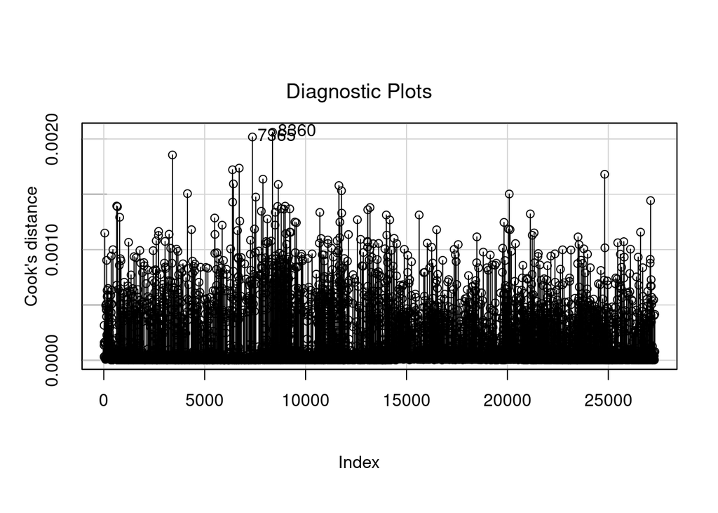

```r
influenceIndexPlot(glm.full, vars = "C")
```

The cook’s distance plot does not give indication of influential points.

Now let’s create a model with only significant predictors:

```r
glm.sig <- glm(murder_prob ~ day_period + year + week_day + COVID_pandemic + vic_age + vic_sex + other_victims + jurisdiction, data=shootings.train, family=binomial)
summary(glm.sig)
```

```
##
## Call:
## glm(formula = murder_prob ~ day_period + year + week_day + COVID_pandemic +
##     vic_age + vic_sex + other_victims + jurisdiction, family = binomial,
##     data = shootings.train)
##
## Coefficients:
##                            Estimate Std. Error z value Pr(>|z|)
## (Intercept)              205.100470  18.969501  10.812  < 2e-16 ***
## day_periodMorning          0.135955   0.175989   0.773  0.43981
## day_periodEarlyAfternoon  -0.067552   0.164712  -0.410  0.68171
## day_periodAfternoon       -0.136442   0.138173  -0.987  0.32341
## day_periodEvening         -0.194008   0.131624  -1.474  0.14049
## day_periodNight           -0.314785   0.122017  -2.580  0.00988 **
## year                      -0.103457   0.009436 -10.964  < 2e-16 ***
## week_dayTuesday            0.052936   0.118526   0.447  0.65515
## week_dayWednesday          0.292630   0.115027   2.544  0.01096 *
## week_dayThursday           0.156025   0.116037   1.345  0.17875
## week_dayFriday             0.048176   0.111970   0.430  0.66701
## week_daySaturday          -0.091489   0.102658  -0.891  0.37282
## week_daySunday            -0.024756   0.099916  -0.248  0.80431
## COVID_pandemicTRUE         0.546696   0.112716   4.850 1.23e-06 ***
## vic_age18-24               0.539069   0.132489   4.069 4.73e-05 ***
## vic_age25-44               1.121735   0.129703   8.649  < 2e-16 ***
## vic_age45+                 1.356324   0.158923   8.534  < 2e-16 ***
## vic_sexM                   0.710752   0.127677   5.567 2.59e-08 ***
## other_victims              0.405408   0.024745  16.383  < 2e-16 ***
## jurisdictionHOUSING       -0.190725   0.082130  -2.322  0.02022 *
## ---
## Signif. codes:  0 '***' 0.001 '**' 0.01 '*' 0.05 '.' 0.1 ' ' 1
##
## (Dispersion parameter for binomial family taken to be 1)
##
##     Null deviance: 8192.3  on 9092  degrees of freedom
## Residual deviance: 7634.0  on 9073  degrees of freedom
## AIC: 7674
##
## Number of Fisher Scoring iterations: 5
```

```r
AIC(glm.sig, glm.full)
```

```
##          df     AIC
## glm.sig  20 7674.01
## glm.full 28 7642.05
```

Now we check for influential points:

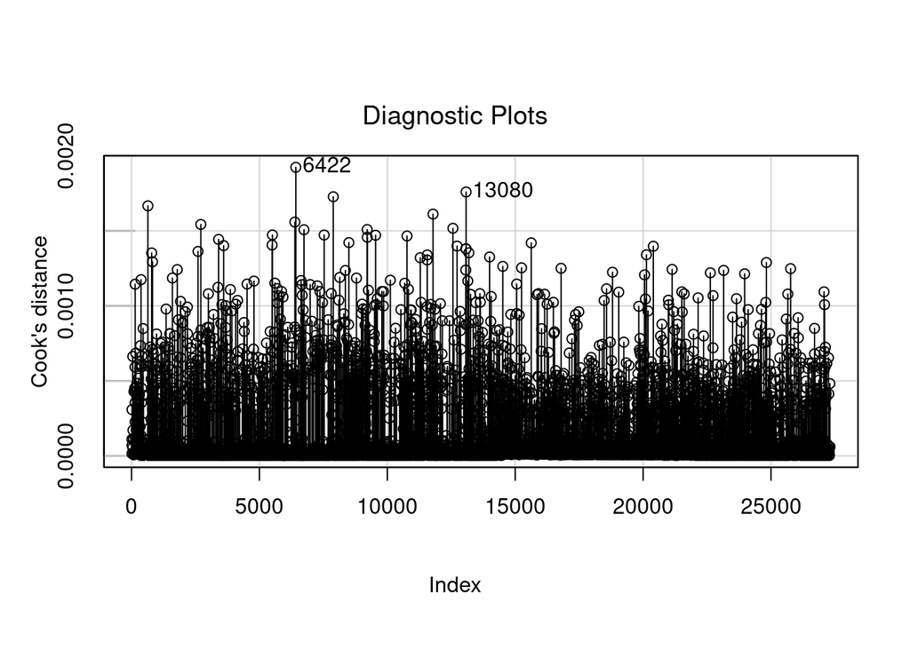

```r
influenceIndexPlot(glm.sig, vars = "C")
```

The cook’s distance plot does not give indication of influential points.

## 4.1 Interaction terms

Now let’s take a look at some interactions. In particular we add to `glm.sig` the following interactions:

- victim sex and victim age
- victim sex and victim race
- victim age and victim race
- year and day of the year

```r
glm.sign.inter <- update(glm.sig, . ~ . + vic_sex:vic_age + vic_sex:vic_race + vic_age:vic_race +year*day_year)
summary(glm.sign.inter)
```

```
##
## Call:
## glm(formula = murder_prob ~ day_period + year + week_day + COVID_pandemic +
##     vic_age + vic_sex + other_victims + jurisdiction + day_year +
##     vic_age:vic_sex + vic_sex:vic_race + vic_age:vic_race + year:day_year,
##     family = binomial, data = shootings.train)
##
## Coefficients:
##                                       Estimate Std. Error z value Pr(>|z|)
## (Intercept)                          2.709e+02  3.159e+01   8.577  < 2e-16 ***
## day_periodMorning                    1.079e-01  1.769e-01   0.610  0.54176
## day_periodEarlyAfternoon            -7.044e-02  1.655e-01  -0.426  0.67045
## day_periodAfternoon                 -1.236e-01  1.388e-01  -0.891  0.37319
## day_periodEvening                   -1.835e-01  1.321e-01  -1.389  0.16482
## day_periodNight                     -3.179e-01  1.224e-01  -2.599  0.00936 **
## year                                -1.357e-01  1.569e-02  -8.649  < 2e-16 ***
## week_dayTuesday                      5.358e-02  1.190e-01   0.450  0.65252
## week_dayWednesday                    2.936e-01  1.158e-01   2.536  0.01122 *
## week_dayThursday                     1.516e-01  1.166e-01   1.300  0.19361
## week_dayFriday                       5.140e-02  1.124e-01   0.457  0.64744
## week_daySaturday                    -8.562e-02  1.032e-01  -0.830  0.40671
## week_daySunday                      -8.886e-03  1.004e-01  -0.089  0.92946
## COVID_pandemicTRUE                   5.237e-01  1.141e-01   4.591 4.41e-06 ***
## vic_age18-24                         5.251e-01  1.196e+00   0.439  0.66062
## vic_age25-44                         6.773e-01  1.167e+00   0.580  0.56163
## vic_age45+                           3.294e-01  1.214e+00   0.271  0.78614
## vic_sexM                             4.656e-02  7.948e-01   0.059  0.95329
## other_victims                        4.106e-01  2.503e-02  16.408  < 2e-16 ***
## jurisdictionHOUSING                 -1.993e-01  8.254e-02  -2.415  0.01575 *
## day_year                            -3.333e-01  1.302e-01  -2.560  0.01048 *
## vic_age18-24:vic_sexM               -8.175e-02  4.761e-01  -0.172  0.86366
## vic_age25-44:vic_sexM                6.751e-02  4.696e-01   0.144  0.88568
## vic_age45+:vic_sexM                  1.067e+00  5.739e-01   1.859  0.06306 .
## vic_sexF:vic_raceBLACK              -8.313e-01  1.218e+00  -0.682  0.49499
## vic_sexM:vic_raceBLACK              -2.854e-01  1.082e+00  -0.264  0.79188
## vic_sexF:vic_raceBLACK HISPANIC     -5.453e-01  1.320e+00  -0.413  0.67948
## vic_sexM:vic_raceBLACK HISPANIC     -3.115e-01  1.147e+00  -0.272  0.78598
## vic_sexF:vic_raceWHITE HISPANIC     -8.769e-01  1.282e+00  -0.684  0.49404
## vic_sexM:vic_raceWHITE HISPANIC     -2.266e-01  1.126e+00  -0.201  0.84050
## vic_age18-24:vic_raceBLACK           1.270e-01  1.136e+00   0.112  0.91101
## vic_age25-44:vic_raceBLACK           4.651e-01  1.108e+00   0.420  0.67473
## vic_age45+:vic_raceBLACK             1.286e-01  1.126e+00   0.114  0.90908
## vic_age18-24:vic_raceBLACK HISPANIC -1.026e-01  1.209e+00  -0.085  0.93239
## vic_age25-44:vic_raceBLACK HISPANIC -3.126e-02  1.181e+00  -0.026  0.97889
## vic_age45+:vic_raceBLACK HISPANIC   -9.429e-01  1.279e+00  -0.737  0.46108
## vic_age18-24:vic_raceWHITE HISPANIC  3.413e-02  1.185e+00   0.029  0.97702
## vic_age25-44:vic_raceWHITE HISPANIC  2.097e-01  1.157e+00   0.181  0.85617
## vic_age45+:vic_raceWHITE HISPANIC    9.856e-02  1.200e+00   0.082  0.93451
## year:day_year                        1.654e-04  6.468e-05   2.557  0.01057 *
## ---
## Signif. codes:  0 '***' 0.001 '**' 0.01 '*' 0.05 '.' 0.1 ' ' 1
##
## (Dispersion parameter for binomial family taken to be 1)
##
##     Null deviance: 8192.3  on 9092  degrees of freedom
## Residual deviance: 7595.8  on 9053  degrees of freedom
## AIC: 7675.8
##
## Number of Fisher Scoring iterations: 5
```

As we can see the interaction between victim predictors are not significant, while the interaction terms between year and day of the year is significant. Let’s remove the not significant interaction:

```r
glm.sign.inter <- update(glm.sign.inter, . ~ . - vic_sex:vic_age - vic_sex:vic_race - vic_age:vic_race)
summary(glm.sign.inter)
```

```
##
## Call:
## glm(formula = murder_prob ~ day_period + year + week_day + COVID_pandemic +
##     vic_age + vic_sex + other_victims + jurisdiction + day_year +
##     year:day_year, family = binomial, data = shootings.train)
##
## Coefficients:
##                            Estimate Std. Error z value Pr(>|z|)
## (Intercept)               2.714e+02  3.140e+01   8.643  < 2e-16 ***
## day_periodMorning         1.311e-01  1.762e-01   0.744  0.45700
## day_periodEarlyAfternoon -6.095e-02  1.649e-01  -0.370  0.71174
## day_periodAfternoon      -1.230e-01  1.384e-01  -0.889  0.37422
## day_periodEvening        -1.808e-01  1.319e-01  -1.371  0.17034
## day_periodNight          -3.052e-01  1.222e-01  -2.497  0.01252 *
## year                     -1.364e-01  1.561e-02  -8.737  < 2e-16 ***
## week_dayTuesday           5.687e-02  1.185e-01   0.480  0.63141
## week_dayWednesday         2.910e-01  1.152e-01   2.527  0.01151 *
## week_dayThursday          1.585e-01  1.161e-01   1.366  0.17209
## week_dayFriday            5.014e-02  1.121e-01   0.447  0.65453
## week_daySaturday         -9.005e-02  1.027e-01  -0.877  0.38074
## week_daySunday           -2.022e-02  9.999e-02  -0.202  0.83972
## COVID_pandemicTRUE        5.309e-01  1.138e-01   4.666 3.07e-06 ***
## vic_age18-24              5.388e-01  1.326e-01   4.064 4.83e-05 ***
## vic_age25-44              1.125e+00  1.298e-01   8.664  < 2e-16 ***
## vic_age45+                1.360e+00  1.591e-01   8.551  < 2e-16 ***
## vic_sexM                  7.131e-01  1.278e-01   5.581 2.39e-08 ***
## other_victims             4.050e-01  2.478e-02  16.344  < 2e-16 ***
## jurisdictionHOUSING      -1.902e-01  8.220e-02  -2.314  0.02067 *
## day_year                 -3.361e-01  1.295e-01  -2.596  0.00942 **
## year:day_year             1.668e-04  6.431e-05   2.593  0.00950 **
## ---
## Signif. codes:  0 '***' 0.001 '**' 0.01 '*' 0.05 '.' 0.1 ' ' 1
##
## (Dispersion parameter for binomial family taken to be 1)
##
##     Null deviance: 8192.3  on 9092  degrees of freedom
## Residual deviance: 7625.9  on 9071  degrees of freedom
## AIC: 7669.9
##
## Number of Fisher Scoring iterations: 5
```

```r
AIC(glm.sign.inter, glm.sig)
```

```
##                df     AIC
## glm.sign.inter 22 7669.87
## glm.sig        20 7674.01
```

The AIC decreases: we prefer the model with interaction.

Now let’s try adding interaction terms to the full model. Now let’s add the following interactions:

- victim sex and victim age
- victim sex and victim race
- victim age and victim race
- year and day of the yea

```r
glm.full.inter <- update(glm.full, . ~ . + vic_sex:vic_age + vic_sex:vic_race + vic_age:vic_race +year*day_year)
summary(glm.full.inter)
```

```
##
## Call:
## glm(formula = murder_prob ~ day_period + day_year + year + week_day +
##     COVID_lockdown + COVID_pandemic + working_hour + Latitude +
##     Longitude + vic_age + vic_sex + vic_race + other_victims +
##     jurisdiction + vic_age:vic_sex + vic_sex:vic_race + vic_age:vic_race +
##     day_year:year, family = binomial, data = shootings.train)
##
## Coefficients:
##                                       Estimate Std. Error z value Pr(>|z|)
## (Intercept)                          3.979e+02  4.968e+01   8.008 1.17e-15 ***
## day_periodMorning                    2.441e-01  2.004e-01   1.218   0.2233
## day_periodEarlyAfternoon             3.387e-02  1.881e-01   0.180   0.8571
## day_periodAfternoon                 -9.026e-02  1.419e-01  -0.636   0.5248
## day_periodEvening                   -1.928e-01  1.326e-01  -1.454   0.1460
## day_periodNight                     -3.148e-01  1.227e-01  -2.565   0.0103 *
## day_year                            -3.309e-01  1.309e-01  -2.527   0.0115 *
## year                                -1.356e-01  1.571e-02  -8.627  < 2e-16 ***
## week_dayTuesday                      7.051e-02  1.193e-01   0.591   0.5545
## week_dayWednesday                    3.088e-01  1.159e-01   2.665   0.0077 **
## week_dayThursday                     1.601e-01  1.168e-01   1.371   0.1705
## week_dayFriday                       5.588e-02  1.127e-01   0.496   0.6200
## week_daySaturday                    -1.058e-01  1.053e-01  -1.005   0.3150
## week_daySunday                      -3.415e-02  1.028e-01  -0.332   0.7397
## COVID_lockdownTRUE                  -6.641e-02  1.430e-01  -0.465   0.6423
## COVID_pandemicTRUE                   5.504e-01  1.246e-01   4.417 1.00e-05 ***
## working_hourTRUE                    -2.073e-01  1.366e-01  -1.518   0.1291
## Latitude                            -1.961e+00  3.709e-01  -5.286 1.25e-07 ***
## Longitude                            6.398e-01  4.560e-01   1.403   0.1606
## vic_age18-24                         4.702e-01  1.194e+00   0.394   0.6936
## vic_age25-44                         6.017e-01  1.164e+00   0.517   0.6053
## vic_age45+                           2.503e-01  1.211e+00   0.207   0.8363
## vic_sexM                             8.445e-02  7.957e-01   0.106   0.9155
## vic_raceBLACK                       -8.032e-01  1.216e+00  -0.660   0.5089
## vic_raceBLACK HISPANIC              -4.186e-01  1.318e+00  -0.318   0.7509
## vic_raceWHITE HISPANIC              -7.361e-01  1.280e+00  -0.575   0.5652
## other_victims                        4.098e-01  2.504e-02  16.361  < 2e-16 ***
## jurisdictionHOUSING                 -1.954e-01  8.318e-02  -2.350   0.0188 *
## vic_age18-24:vic_sexM               -8.002e-02  4.767e-01  -0.168   0.8667
## vic_age25-44:vic_sexM                7.978e-02  4.705e-01   0.170   0.8653
```

[output cut: 9 more lines]

```
## vic_age45+:vic_raceBLACK HISPANIC   -8.981e-01  1.277e+00  -0.703   0.4818
## vic_age18-24:vic_raceWHITE HISPANIC  9.756e-02  1.182e+00   0.083   0.9342
## vic_age25-44:vic_raceWHITE HISPANIC  2.833e-01  1.153e+00   0.246   0.8060
## vic_age45+:vic_raceWHITE HISPANIC    1.395e-01  1.196e+00   0.117   0.9071
## day_year:year                        1.642e-04  6.503e-05   2.525   0.0116 *
## ---
## Signif. codes:  0 '***' 0.001 '**' 0.01 '*' 0.05 '.' 0.1 ' ' 1
##
## (Dispersion parameter for binomial family taken to be 1)
##
##     Null deviance: 8192.3  on 9092  degrees of freedom
## Residual deviance: 7563.8  on 9049  degrees of freedom
## AIC: 7651.8
##
## Number of Fisher Scoring iterations: 5
```

As before the interaction between victim predictors are not significant. Instead the interaction between year and day of the year is significant. Let’s remove the not significant interaction:

```r
glm.full.inter <- update(glm.full.inter, . ~ . - vic_sex:vic_age - vic_sex:vic_race - vic_age:vic_race)
summary(glm.full.inter)
```

```
##
## Call:
## glm(formula = murder_prob ~ day_period + day_year + year + week_day +
##     COVID_lockdown + COVID_pandemic + working_hour + Latitude +
##     Longitude + vic_age + vic_sex + vic_race + other_victims +
##     jurisdiction + day_year:year, family = binomial, data = shootings.train)
##
## Coefficients:
##                            Estimate Std. Error z value Pr(>|z|)
## (Intercept)               3.967e+02  4.949e+01   8.017 1.09e-15 ***
## day_periodMorning         2.546e-01  1.999e-01   1.273   0.2029
## day_periodEarlyAfternoon  3.416e-02  1.876e-01   0.182   0.8555
## day_periodAfternoon      -1.015e-01  1.416e-01  -0.716   0.4739
## day_periodEvening        -2.004e-01  1.324e-01  -1.513   0.1302
## day_periodNight          -3.144e-01  1.226e-01  -2.564   0.0103 *
## day_year                 -3.289e-01  1.304e-01  -2.522   0.0117 *
## year                     -1.354e-01  1.565e-02  -8.651  < 2e-16 ***
## week_dayTuesday           6.761e-02  1.189e-01   0.568   0.5698
## week_dayWednesday         2.943e-01  1.154e-01   2.550   0.0108 *
## week_dayThursday          1.587e-01  1.165e-01   1.362   0.1731
## week_dayFriday            5.048e-02  1.124e-01   0.449   0.6532
## week_daySaturday         -1.120e-01  1.049e-01  -1.068   0.2854
## week_daySunday           -4.788e-02  1.025e-01  -0.467   0.6403
## COVID_lockdownTRUE       -7.171e-02  1.426e-01  -0.503   0.6150
## COVID_pandemicTRUE        5.562e-01  1.241e-01   4.481 7.44e-06 ***
## working_hourTRUE         -2.180e-01  1.363e-01  -1.599   0.1098
## Latitude                 -1.940e+00  3.700e-01  -5.244 1.57e-07 ***
## Longitude                 6.506e-01  4.551e-01   1.430   0.1528
## vic_age18-24              5.233e-01  1.328e-01   3.939 8.17e-05 ***
## vic_age25-44              1.099e+00  1.301e-01   8.444  < 2e-16 ***
## vic_age45+                1.335e+00  1.601e-01   8.339  < 2e-16 ***
## vic_sexM                  7.201e-01  1.281e-01   5.621 1.90e-08 ***
## vic_raceBLACK            -2.109e-02  1.742e-01  -0.121   0.9036
## vic_raceBLACK HISPANIC   -3.052e-01  2.057e-01  -1.484   0.1378
## vic_raceWHITE HISPANIC   -2.883e-02  1.938e-01  -0.149   0.8817
## other_victims             4.100e-01  2.492e-02  16.452  < 2e-16 ***
## jurisdictionHOUSING      -1.948e-01  8.308e-02  -2.345   0.0190 *
## day_year:year             1.632e-04  6.478e-05   2.519   0.0118 *
## ---
## Signif. codes:  0 '***' 0.001 '**' 0.01 '*' 0.05 '.' 0.1 ' ' 1
##
## (Dispersion parameter for binomial family taken to be 1)
##
##     Null deviance: 8192.3  on 9092  degrees of freedom
## Residual deviance: 7579.7  on 9064  degrees of freedom
## AIC: 7637.7
##
## Number of Fisher Scoring iterations: 5
```

Check AIC:

```r
AIC(glm.full)
```

```
## [1] 7642.05
```

```r
AIC(glm.full.inter)
```

```
## [1] 7637.653
```

The AIC decrease suggests that the full model with interaction is better compared to the full model.

In summary the models with interaction are preferable. Now let’s compare the two models with interaction:

```r
AIC(glm.full.inter)
```

```
## [1] 7637.653
```

```r
AIC(glm.sign.inter)
```

```
## [1] 7669.87
```

In terms of AIC we prefer the full model with interaction.

Let’s interpret what the best model in terms of AIC tell us.

```r
summary(glm.full.inter)
```

```
##
## Call:
## glm(formula = murder_prob ~ day_period + day_year + year + week_day +
##     COVID_lockdown + COVID_pandemic + working_hour + Latitude +
##     Longitude + vic_age + vic_sex + vic_race + other_victims +
##     jurisdiction + day_year:year, family = binomial, data = shootings.train)
##
## Coefficients:
##                            Estimate Std. Error z value Pr(>|z|)
## (Intercept)               3.967e+02  4.949e+01   8.017 1.09e-15 ***
## day_periodMorning         2.546e-01  1.999e-01   1.273   0.2029
## day_periodEarlyAfternoon  3.416e-02  1.876e-01   0.182   0.8555
## day_periodAfternoon      -1.015e-01  1.416e-01  -0.716   0.4739
## day_periodEvening        -2.004e-01  1.324e-01  -1.513   0.1302
## day_periodNight          -3.144e-01  1.226e-01  -2.564   0.0103 *
## day_year                 -3.289e-01  1.304e-01  -2.522   0.0117 *
## year                     -1.354e-01  1.565e-02  -8.651  < 2e-16 ***
## week_dayTuesday           6.761e-02  1.189e-01   0.568   0.5698
## week_dayWednesday         2.943e-01  1.154e-01   2.550   0.0108 *
## week_dayThursday          1.587e-01  1.165e-01   1.362   0.1731
## week_dayFriday            5.048e-02  1.124e-01   0.449   0.6532
## week_daySaturday         -1.120e-01  1.049e-01  -1.068   0.2854
## week_daySunday           -4.788e-02  1.025e-01  -0.467   0.6403
## COVID_lockdownTRUE       -7.171e-02  1.426e-01  -0.503   0.6150
## COVID_pandemicTRUE        5.562e-01  1.241e-01   4.481 7.44e-06 ***
## working_hourTRUE         -2.180e-01  1.363e-01  -1.599   0.1098
## Latitude                 -1.940e+00  3.700e-01  -5.244 1.57e-07 ***
## Longitude                 6.506e-01  4.551e-01   1.430   0.1528
## vic_age18-24              5.233e-01  1.328e-01   3.939 8.17e-05 ***
## vic_age25-44              1.099e+00  1.301e-01   8.444  < 2e-16 ***
## vic_age45+                1.335e+00  1.601e-01   8.339  < 2e-16 ***
## vic_sexM                  7.201e-01  1.281e-01   5.621 1.90e-08 ***
## vic_raceBLACK            -2.109e-02  1.742e-01  -0.121   0.9036
## vic_raceBLACK HISPANIC   -3.052e-01  2.057e-01  -1.484   0.1378
## vic_raceWHITE HISPANIC   -2.883e-02  1.938e-01  -0.149   0.8817
## other_victims             4.100e-01  2.492e-02  16.452  < 2e-16 ***
## jurisdictionHOUSING      -1.948e-01  8.308e-02  -2.345   0.0190 *
## day_year:year             1.632e-04  6.478e-05   2.519   0.0118 *
## ---
## Signif. codes:  0 '***' 0.001 '**' 0.01 '*' 0.05 '.' 0.1 ' ' 1
##
## (Dispersion parameter for binomial family taken to be 1)
##
##     Null deviance: 8192.3  on 9092  degrees of freedom
## Residual deviance: 7579.7  on 9064  degrees of freedom
## AIC: 7637.7
##
## Number of Fisher Scoring iterations: 5
```

Let’s plot the effects for all the interactionless variables:

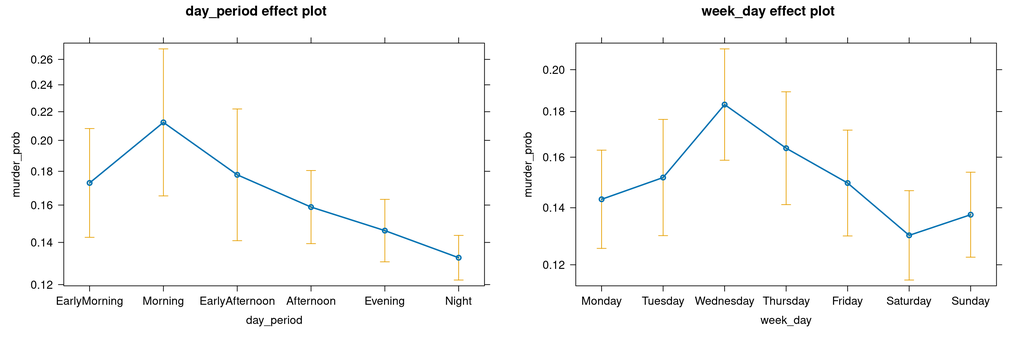

```r
eff <- head(allEffects(glm.full.inter),-1)

plot(head(eff,2))
```

As we can see:

- during the late hours of the day it is more likely for the victim to survive a shooting incident.
- during the weekend it is more likely for the victim to survive a shooting incident.

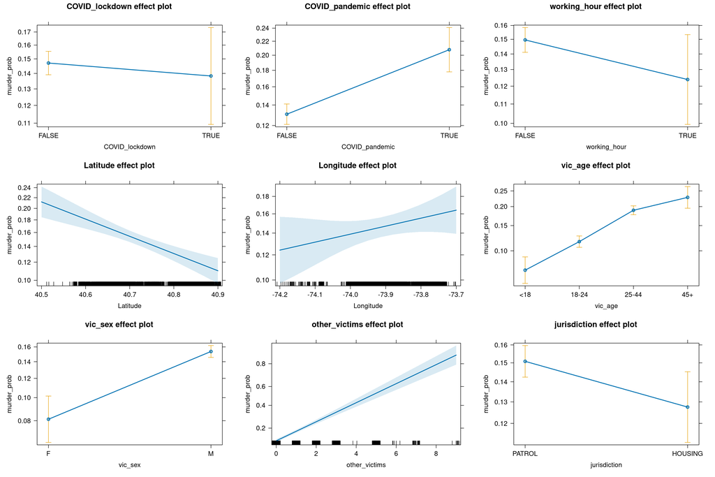

```r
eff <- head(allEffects(glm.full.inter),-1)
eff[1] <- NULL
eff[1] <- NULL
eff[8] <- NULL

plot(eff)
```

As we can see:

- COVID lockdown effect is not significant as the confidence bands tells us.
- it is less likely for a victim to survive during COVID pandemic period.
- the working hour effect is not significant as the confidence bands tells us.
- as Latitude increases the more likely for the victim to survive, while Longitude is not significant as the confidence bands tells us.
- the more old the victim is the less likely for him/her is to survive.
- males victims are less likely to survive.
- as the number of additional victims grows the less likely for the victim is to survive.
- if the jurisdiction of the shooting incident is patrol it is less likely for the victim to survive.

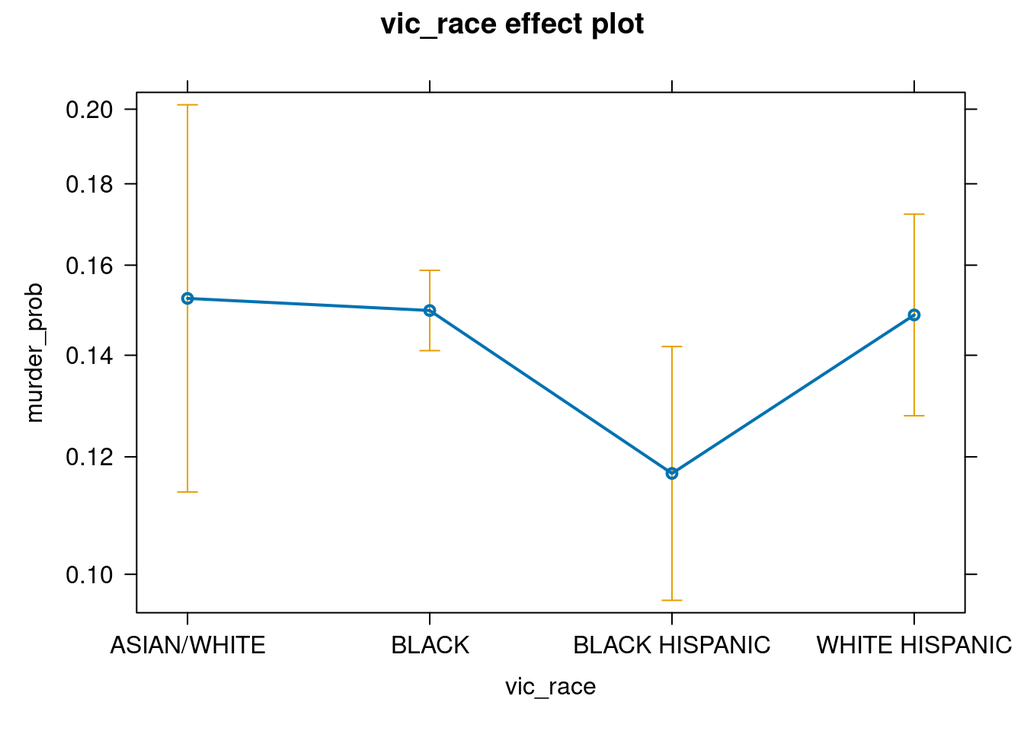

```r
plot(effect("vic_race", glm.full.inter))
```

As we can see if the victim is “BLACK HISPANIC” it is more likely for him/her to survive.

Now let’s plot interaction:

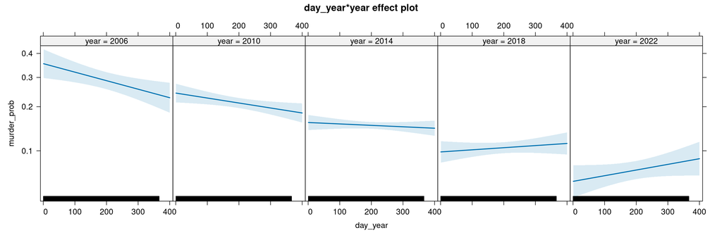

```r
eff <- allEffects(glm.full.inter)[length(allEffects(glm.full.inter))]
plot(eff)
```

As we can see as the years grows the effect of the day of the year on murder probability decreases and from negative correlated becomes positive correlated with murder probability.

## 4.2 Model comparison

Let’s compare all the models done so far in terms of prediction power to be able to compare them with other types of models:

```r
glm.full.pred <- predict(glm.full, newdata = shootings.test, type = "response")

glm.sig.pred <- predict(glm.sig, newdata = shootings.test, type = "response")

glm.full.inter.pred <- predict(glm.full.inter, newdata = shootings.test, type = "response")

glm.sig.inter.pred <- predict(glm.sign.inter, newdata = shootings.test, type = "response")
```

Select the best threshold via ROC curve:

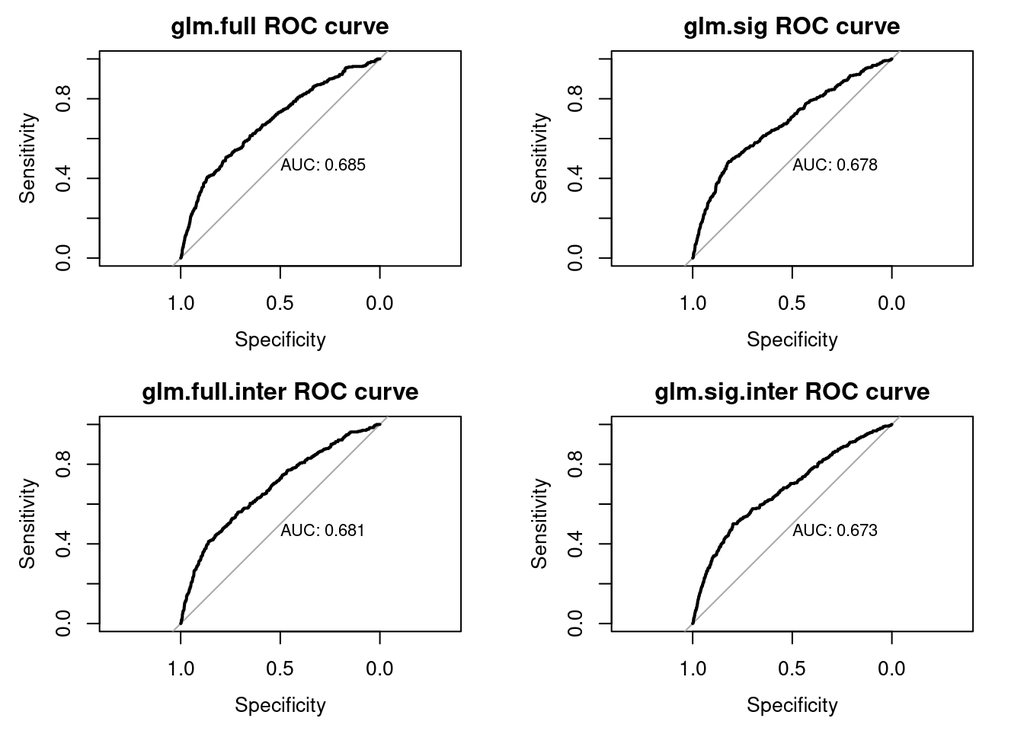

```r
par(mfrow=c(2,2))

glm.full.roc <- roc(shootings.test$murder_prob ~ glm.full.pred, plot=TRUE, print.auc=TRUE, main="glm.full ROC curve")
glm.sig.roc <- roc(shootings.test$murder_prob ~ glm.sig.pred, plot=TRUE, print.auc=TRUE, main="glm.sig ROC curve")

glm.full.inter.roc <- roc(shootings.test$murder_prob ~ glm.full.inter.pred, plot=TRUE, print.auc=TRUE, main="glm.full.inter ROC curve")
glm.sig.inter.roc <- roc(shootings.test$murder_prob ~ glm.sig.inter.pred, plot=TRUE, print.auc=TRUE, main="glm.sig.inter ROC curve")
```

```r
glm.full.metrics <- coords(glm.full.roc, x="best", ret="all")
glm.sig.metrics <- coords(glm.sig.roc, x="best", ret="all")
glm.full.inter.metrics <- coords(glm.full.inter.roc, x="best", ret="all")
glm.sig.inter.metrics <- coords(glm.sig.inter.roc, x="best", ret="all")
```

```r
row.names(glm.full.metrics) <- "Full model"
row.names(glm.sig.metrics) <- "Significant predictors model"
row.names(glm.full.inter.metrics) <- "Full model with interaction"
row.names(glm.sig.inter.metrics) <- "Significant predictors model with interaction"

metrics <- rbind(glm.full.metrics, glm.sig.metrics, glm.full.inter.metrics, glm.sig.inter.metrics)
```

Now let’s compare:

1. specificity

```r
(metrics %>% arrange(desc(specificity)))[, c("specificity", "sensitivity", "accuracy")]
```

```
##                                               specificity sensitivity  accuracy
## Full model with interaction                     0.8602207   0.4123989 0.7871592
## Significant predictors model                    0.8187073   0.4851752 0.7642920
## Significant predictors model with interaction   0.7961114   0.5013477 0.7480211
## Full model                                      0.7724645   0.5067385 0.7291117
```

The best model in terms of specificity is “Full model with interaction”.

2. sensitivity

```r
(metrics %>% arrange(desc(sensitivity)))[, c("specificity", "sensitivity", "accuracy")]
```

```
##                                               specificity sensitivity  accuracy
## Full model                                      0.7724645   0.5067385 0.7291117
## Significant predictors model with interaction   0.7961114   0.5013477 0.7480211
## Significant predictors model                    0.8187073   0.4851752 0.7642920
## Full model with interaction                     0.8602207   0.4123989 0.7871592
```

The best model in terms of sensitivity is “Full model”.

3. accuracy

```r
(metrics %>% arrange(desc(accuracy)))[, c("specificity", "sensitivity", "accuracy")]
```

```
##                                               specificity sensitivity  accuracy
## Full model with interaction                     0.8602207   0.4123989 0.7871592
## Significant predictors model                    0.8187073   0.4851752 0.7642920
## Significant predictors model with interaction   0.7961114   0.5013477 0.7480211
## Full model                                      0.7724645   0.5067385 0.7291117
```

The best model in terms of accuracy is “Full model with interaction”.

Since the response in unbalanced:

```r
print(dfSummary(shootings.test[,"murder_prob"]), method="render")
```

**No**

**Variable**

**Stats / Values**

**Freqs (% of Valid)**

**Graph**

**Valid**

**Missing**

1

murder_prob [numeric]

| Min : 0 |
| --- |
| Mean : 0.2 |
| Max : 1 |

| 0 | : | 1903 | ( | 83.7% | ) |
| --- | --- | --- | --- | --- | --- |
| 1 | : | 371 | ( | 16.3% | ) |

2274 (100.0%)

0 (0.0%)

Generated by summarytools 1.0.1 ([R](https://www.r-project.org/) version 4.3.2)  
2024-01-19

The best model in terms of prediction power should maximize its ability to correctly classify murders. For this reason i should choose the model with higher sensitivity and acceptable specificity (>0.5): “Full model”.

#### 4.2.0.1 Confusion Matrixes

```r
confusion_matrix <- function(pred_prob, threshold){
  pred_class <- pred_prob > threshold
  table(preds=pred_class, true=as.logical(shootings.test$murder_prob))
}
```

1. Full model

```r
glm.full.metrics[, c("specificity", "sensitivity", "accuracy")]
```

```
##            specificity sensitivity  accuracy
## Full model   0.7724645   0.5067385 0.7291117
```

```r
confusion_matrix(glm.full.pred, glm.full.metrics$threshold)
```

```
##        true
## preds   FALSE TRUE
##   FALSE  1470  183
##   TRUE    433  188
```

2. Full model with interaction

```r
glm.full.inter.metrics[, c("specificity", "sensitivity", "accuracy")]
```

```
##                             specificity sensitivity  accuracy
## Full model with interaction   0.8602207   0.4123989 0.7871592
```

```r
confusion_matrix(glm.full.inter.pred, glm.full.inter.metrics$threshold)
```

```
##        true
## preds   FALSE TRUE
##   FALSE  1637  218
##   TRUE    266  153
```

3. Significant predictors model

```r
glm.sig.metrics[, c("specificity", "sensitivity", "accuracy")]
```

```
##                              specificity sensitivity accuracy
## Significant predictors model   0.8187073   0.4851752 0.764292
```

```r
confusion_matrix(glm.sig.pred, glm.sig.metrics$threshold)
```

```
##        true
## preds   FALSE TRUE
##   FALSE  1558  191
##   TRUE    345  180
```

4. Significant predictors model with interaction

```r
glm.sig.inter.metrics[, c("specificity", "sensitivity", "accuracy")]
```

```
##                                               specificity sensitivity  accuracy
## Significant predictors model with interaction   0.7961114   0.5013477 0.7480211
```

```r
confusion_matrix(glm.sig.inter.pred, glm.sig.inter.metrics$threshold)
```

```
##        true
## preds   FALSE TRUE
##   FALSE  1515  185
##   TRUE    388  186
```

## 4.3 Model selection

Now let’s apply automatic model selection to identity the best model.

### 4.3.1 Stepwiese logistic regression

We use the model which has the most predictors and interaction terms as starting point.

```r
model <- glm(murder_prob ~ . + vic_sex:vic_age + vic_sex:vic_race + vic_age:vic_race +year*day_year, family = binomial, data = shootings.train)
glm.step <- step(model, direction = "both", trace = FALSE)
```

```r
summary(glm.step)
```

```
##
## Call:
## glm(formula = murder_prob ~ day_period + day_year + year + week_day +
##     COVID_pandemic + working_hour + Latitude + Longitude + vic_age +
##     vic_sex + vic_race + other_victims + jurisdiction + vic_age:vic_sex +
##     day_year:year, family = binomial, data = shootings.train)
##
## Coefficients:
##                            Estimate Std. Error z value Pr(>|z|)
## (Intercept)               3.997e+02  4.957e+01   8.063 7.46e-16 ***
## day_periodMorning         2.564e-01  2.001e-01   1.282  0.19997
## day_periodEarlyAfternoon  3.680e-02  1.878e-01   0.196  0.84464
## day_periodAfternoon      -9.052e-02  1.417e-01  -0.639  0.52308
## day_periodEvening        -1.905e-01  1.326e-01  -1.437  0.15063
## day_periodNight          -3.121e-01  1.227e-01  -2.544  0.01095 *
## day_year                 -3.415e-01  1.304e-01  -2.619  0.00883 **
## year                     -1.363e-01  1.570e-02  -8.677  < 2e-16 ***
## week_dayTuesday           7.114e-02  1.191e-01   0.597  0.55033
## week_dayWednesday         3.056e-01  1.156e-01   2.644  0.00818 **
## week_dayThursday          1.628e-01  1.167e-01   1.395  0.16289
## week_dayFriday            5.182e-02  1.125e-01   0.461  0.64508
## week_daySaturday         -1.040e-01  1.050e-01  -0.990  0.32204
## week_daySunday           -3.979e-02  1.026e-01  -0.388  0.69813
## COVID_pandemicTRUE        5.294e-01  1.141e-01   4.639 3.50e-06 ***
## working_hourTRUE         -2.128e-01  1.363e-01  -1.561  0.11849
## Latitude                 -1.959e+00  3.703e-01  -5.292 1.21e-07 ***
## Longitude                 6.555e-01  4.550e-01   1.441  0.14963
## vic_age18-24              5.927e-01  4.552e-01   1.302  0.19293
## vic_age25-44              9.989e-01  4.499e-01   2.220  0.02639 *
## vic_age45+                3.644e-01  5.402e-01   0.675  0.49995
## vic_sexM                  5.409e-01  4.314e-01   1.254  0.20992
## vic_raceBLACK            -1.667e-02  1.746e-01  -0.096  0.92390
## vic_raceBLACK HISPANIC   -3.017e-01  2.060e-01  -1.464  0.14309
## vic_raceWHITE HISPANIC   -1.246e-02  1.942e-01  -0.064  0.94885
## other_victims             4.105e-01  2.491e-02  16.479  < 2e-16 ***
## jurisdictionHOUSING      -1.951e-01  8.306e-02  -2.349  0.01882 *
## vic_age18-24:vic_sexM    -7.000e-02  4.758e-01  -0.147  0.88303
## vic_age25-44:vic_sexM     1.127e-01  4.689e-01   0.240  0.81001
## vic_age45+:vic_sexM       1.083e+00  5.646e-01   1.919  0.05499 .
## day_year:year             1.694e-04  6.478e-05   2.616  0.00890 **
## ---
## Signif. codes:  0 '***' 0.001 '**' 0.01 '*' 0.05 '.' 0.1 ' ' 1
##
## (Dispersion parameter for binomial family taken to be 1)
##
##     Null deviance: 8192.3  on 9092  degrees of freedom
## Residual deviance: 7571.0  on 9062  degrees of freedom
## AIC: 7633
##
## Number of Fisher Scoring iterations: 5
```

```r
AIC(glm.full, glm.full.inter, glm.sig, glm.sign.inter, glm.step) %>% arrange(AIC)
```

```
##                df      AIC
## glm.step       31 7632.958
## glm.full.inter 29 7637.653
## glm.full       28 7642.050
## glm.sign.inter 22 7669.870
## glm.sig        20 7674.010
```

In terms of AIC the step model is the best.

#### 4.3.1.1 Model comparison

Let’s compare the step model with the models done so far.

```r
glm.step.pred <- predict(glm.step, newdata = shootings.test, type = "response")
```

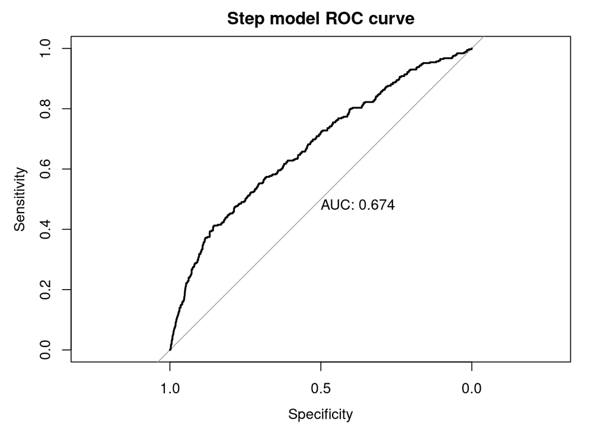

```r
glm.step.roc <- roc(shootings.test$murder_prob ~ glm.step.pred, plot=TRUE, print.auc=TRUE, main="Step model ROC curve")
```

```r
glm.step.metrics <- coords(glm.step.roc, x="best", ret="all")
rownames(glm.step.metrics) <- "Step model"
```

```r
metrics <- rbind(metrics, glm.step.metrics)
```

```r
(metrics %>% arrange(desc(sensitivity)))[, c("specificity", "sensitivity", "accuracy")]
```

```
##                                               specificity sensitivity  accuracy
## Full model                                      0.7724645   0.5067385 0.7291117
## Significant predictors model with interaction   0.7961114   0.5013477 0.7480211
## Significant predictors model                    0.8187073   0.4851752 0.7642920
## Full model with interaction                     0.8602207   0.4123989 0.7871592
## Step model                                      0.8539149   0.4123989 0.7818821
```

The step model is the worst in terms of sensitivity but has good specificity and accuracy.

Confusion matrix for step model:

```r
confusion_matrix(glm.step.pred, glm.step.metrics$threshold)
```

```
##        true
## preds   FALSE TRUE
##   FALSE  1625  218
##   TRUE    278  153
```

### 4.3.2 Lasso Regression

Now we try with lasso regression. As before we use as starting point the formula with all predictors and interactions term.

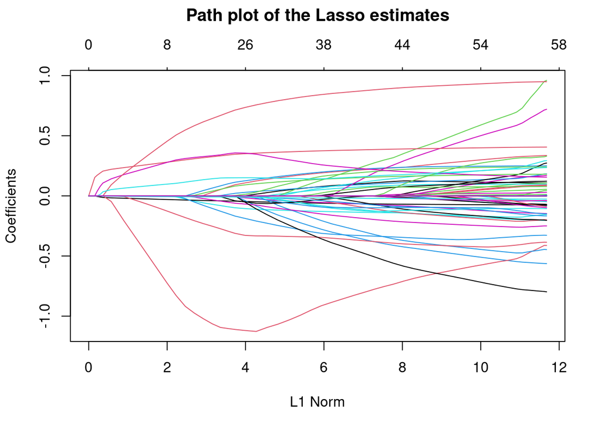

```r
lasso.mod <- glmnet(murder_prob ~ . + vic_sex:vic_age + vic_sex:vic_race + vic_age:vic_race +year*day_year, data=shootings.train, alpha=1, family = "binomial")
plot(lasso.mod, main='Path plot of the Lasso estimates\n\n')
```

We choose lambda using cross validation:

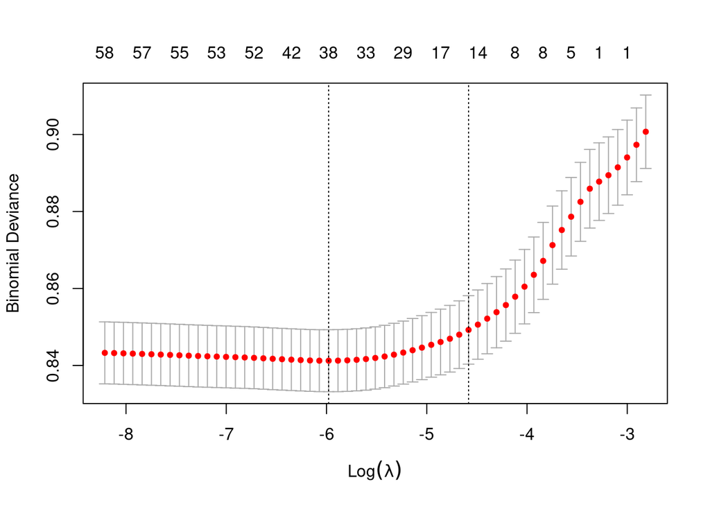

```r
lasso.cv <- cv.glmnet(murder_prob ~ . + vic_sex:vic_age + vic_sex:vic_race + vic_age:vic_race +year*day_year, data=shootings.train, alpha=1, family = "binomial")
plot(lasso.cv)
```

Lasso gives us the choice between two values of lambda:

- `lambda.min`: lambda of minimum mean cross-validated error.
- `lambda.1se`: largest value of lambda such that error is within 1 standard error of the cross-validated errors for `lambda.min`.

We explore both paths.

#### 4.3.2.1 1se lambda

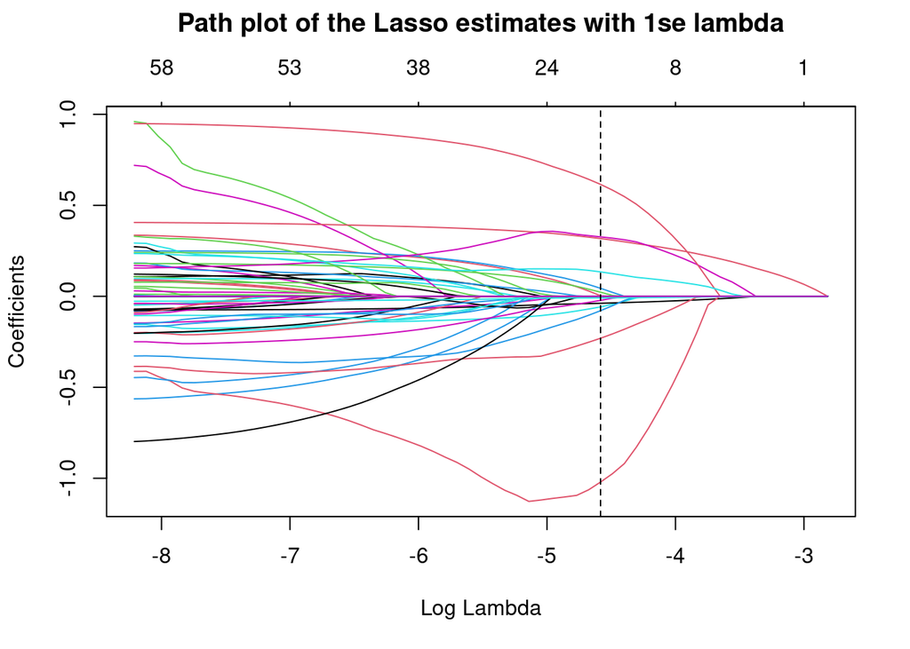

```r
plot(lasso.mod, xvar = "lambda", main='Path plot of the Lasso estimates with 1se lambda\n\n')
abline(v = log(lasso.cv$lambda.1se), lty="dashed")
```

The remaining coefficients are:

```r
lasso.1se.coef <- coef(lasso.mod,  s=lasso.cv$lambda.1se)

lasso.1se.coef[lasso.1se.coef[,1]!=0,]
```

```
##                (Intercept)          day_periodMorning
##               1.337435e+02               3.039282e-03
##            day_periodNight                       year
##              -5.819404e-02              -3.827428e-02
##          week_dayWednesday                   Latitude
##               4.411227e-02              -1.020803e+00
##       city_locationW_Bronx                 vic_age<18
##              -2.234577e-02              -2.303783e-01
##                   vic_sexF                   vic_sexM
##              -7.894533e-02               1.200859e-13
##              other_victims         jurisdictionPATROL
##               3.173873e-01               2.261788e-02
##      vic_sexM:vic_age25-44        vic_sexM:vic_age45+
##               3.266684e-01               6.151306e-01
## vic_age25-44:vic_raceBLACK                       year
##               1.341907e-01              -8.468840e-03
```

#### 4.3.2.2 min lambda

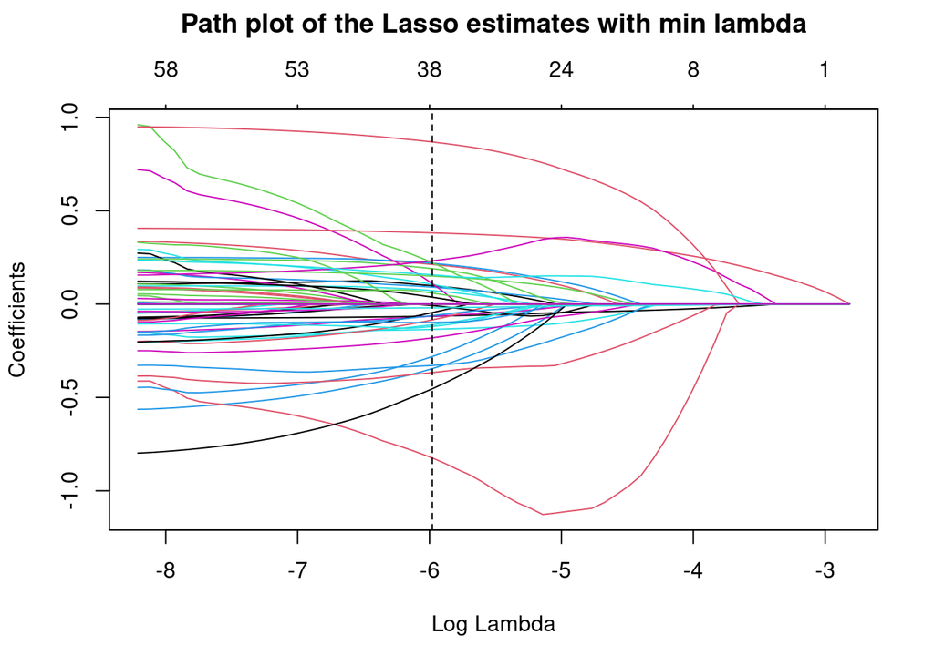

```r
plot(lasso.mod, xvar = "lambda", main='Path plot of the Lasso estimates with min lambda\n\n')
abline(v =log(lasso.cv$lambda.min), lty="dashed")
```

The remaining coefficients are:

```r
lasso.min.coef <- coef(lasso.mod,  s=lasso.cv$lambda.min)
lasso.min.coef[lasso.min.coef[,1]!=0,]
```

```
##                       (Intercept)            day_periodEarlyMorning
##                      2.182626e+02                      9.810807e-02
##                 day_periodMorning                   day_periodNight
##                      2.123954e-01                     -1.355064e-01
##                          day_year                              year
##                     -6.571919e-05                     -6.478140e-02
##                 week_dayWednesday                  week_dayThursday
##                      2.184574e-01                      7.196622e-02
##                  week_daySaturday               COVID_pandemicFALSE
##                     -6.517379e-02                     -3.455705e-01
##                COVID_pandemicTRUE                          Latitude
##                      1.758100e-13                     -8.240382e-01
##                         Longitude          city_locationS_Manhattan
##                      2.216031e-01                     -2.810892e-01
##          city_locationN_Manhattan              city_locationW_Bronx
##                     -1.106834e-01                     -1.808661e-01
##           city_locationN_W_Queens         city_locationS_E_Brooklyn
##                     -8.467738e-02                      9.070611e-02
##         city_locationS_W_Brooklyn      city_locationW_Staten_Island
##                      1.053407e-01                      1.096701e-01
##                        vic_age<18                      vic_age25-44
##                     -3.668392e-01                      1.898743e-01
##                          vic_sexF                          vic_sexM
##                     -3.286601e-01                      5.753454e-13
##            vic_raceBLACK HISPANIC                     other_victims
##                     -7.770607e-03                      3.814229e-01
##                jurisdictionPATROL             vic_sexM:vic_age25-44
##                      1.497872e-01                      2.315465e-01
##               vic_sexF:vic_age45+               vic_sexM:vic_age45+
##                     -4.539083e-02                      8.681424e-01
##            vic_sexF:vic_raceBLACK   vic_sexM:vic_raceBLACK HISPANIC
##                     -6.192999e-02                     -1.199734e-01
##   vic_sexM:vic_raceWHITE HISPANIC    vic_age45+:vic_raceASIAN/WHITE
##                      3.687836e-02                      5.909635e-02
##          vic_age<18:vic_raceBLACK        vic_age25-44:vic_raceBLACK
##                     -9.805697e-02                      1.567763e-01
## vic_age45+:vic_raceBLACK HISPANIC                              year
##                     -4.535443e-01                     -1.971378e-02
##                          day_year
##                     -2.255408e-05
```

#### 4.3.2.3 Model comparison

Now let’s compare prediction performance of lasso models.

```r
lasso.1se.pred <- predict(lasso.mod, s=lasso.cv$lambda.1se, newdata = shootings.test, type = "response")
lasso.min.pred <- predict(lasso.mod, s=lasso.cv$lambda.min, newdata = shootings.test, type = "response")
```

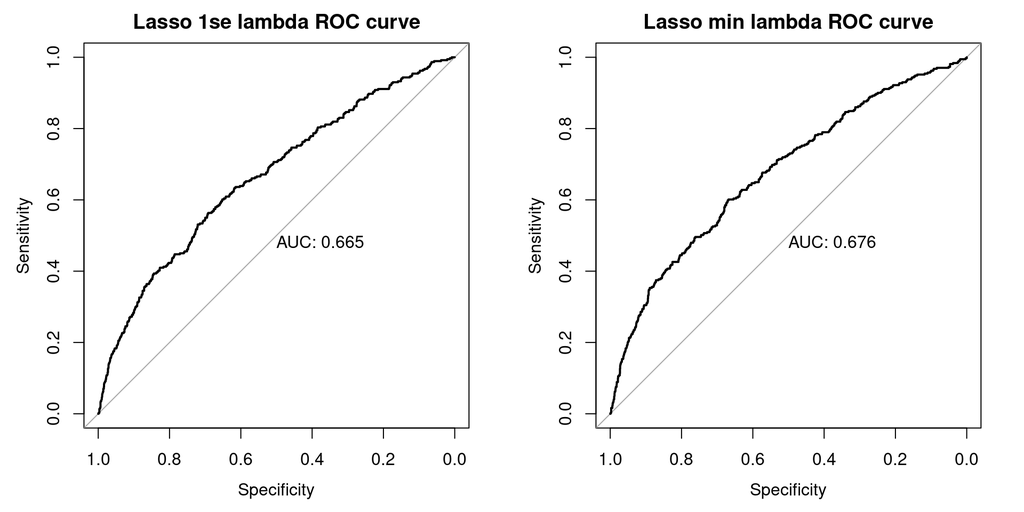

```r
par(mfrow=c(1,2))

lasso.1se.roc <- roc(shootings.test$murder_prob ~ lasso.1se.pred, plot=TRUE, print.auc=TRUE, main="Lasso 1se lambda ROC curve")
lasso.min.roc <- roc(shootings.test$murder_prob ~ lasso.min.pred, plot=TRUE, print.auc=TRUE, main="Lasso min lambda ROC curve")
```

According to the ROC curve the Lasso model with min lambda is better than the one with 1se lambda.

```r
lasso.1se.metrics <- coords(lasso.1se.roc, x="best", ret="all")
row.names(lasso.1se.metrics) <- "Lasso 1se lambda"

lasso.min.metrics <- coords(lasso.min.roc, x="best", ret="all")
row.names(lasso.min.metrics) <- "Lasso min lambda"
```

```r
metrics <- rbind(metrics, lasso.1se.metrics, lasso.min.metrics)
```

```r
(metrics %>% arrange(desc(sensitivity)))[, c("specificity", "sensitivity", "accuracy")]
```

```
##                                               specificity sensitivity  accuracy
## Lasso min lambda                                0.6684183   0.6010782 0.6574318
## Lasso 1se lambda                                0.6915397   0.5633423 0.6706245
## Full model                                      0.7724645   0.5067385 0.7291117
## Significant predictors model with interaction   0.7961114   0.5013477 0.7480211
## Significant predictors model                    0.8187073   0.4851752 0.7642920
## Full model with interaction                     0.8602207   0.4123989 0.7871592
## Step model                                      0.8539149   0.4123989 0.7818821
```

As we can see “Lasso min lambda” is the best model in terms of sensitivity now. The model “Lasso 1se lambda” is the second best model in terms of sensitivity now. Thus the best overall model for now is “Lasso min lambda”

Confusion Matrix for `lambda.1se`:

```r
confusion_matrix(lasso.1se.pred, lasso.1se.metrics$threshold)
```

```
##        true
## preds   FALSE TRUE
##   FALSE  1316  162
##   TRUE    587  209
```

Confusion Matrix for `lambda.min`:

```r
confusion_matrix(lasso.min.pred, lasso.min.metrics$threshold)
```

```
##        true
## preds   FALSE TRUE
##   FALSE  1272  148
##   TRUE    631  223
```

### 4.3.3 Ridge logistic regression

Now we try with ridge regression. As before we use as starting point the formula with all predictors and interaction term.

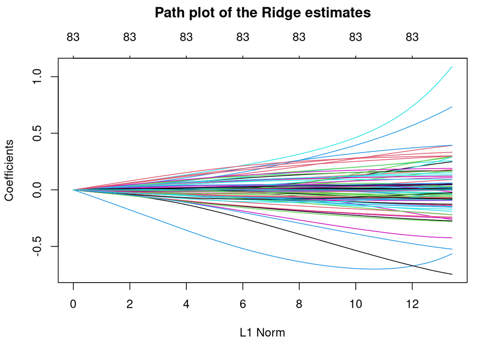

```r
ridge.mod <- glmnet(murder_prob ~ . + vic_sex:vic_age + vic_sex:vic_race + vic_age:vic_race +year*day_year, data=shootings.train, alpha=0, family = binomial)
plot(ridge.mod, main='Path plot of the Ridge estimates\n\n')
```

We choose lambda using cross validation:

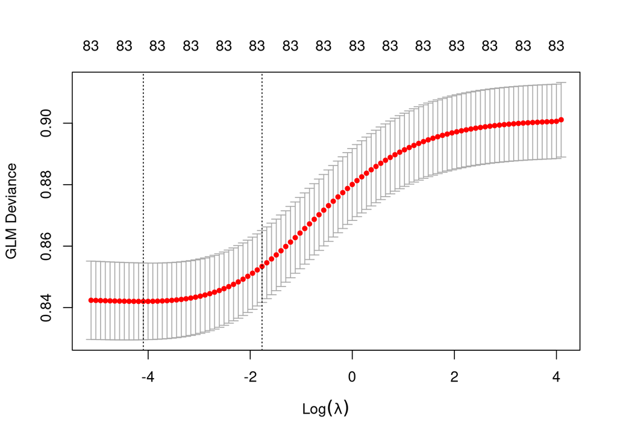

```r
ridge.cv <- cv.glmnet(murder_prob ~ . + vic_sex:vic_age + vic_sex:vic_race + vic_age:vic_race +year*day_year, data=shootings.train, alpha=0, family = binomial)
plot(ridge.cv)
```

Ridge (as Lasso) gives us the choice between two values of lambda:

- `lambda.min`: lambda of minimum mean cross-validated error.
- `lambda.1se`: largest value of lambda such that error is within 1 standard error of the cross-validated errors for `lambda.min`.

We explore both paths.

#### 4.3.3.1 1se lambda

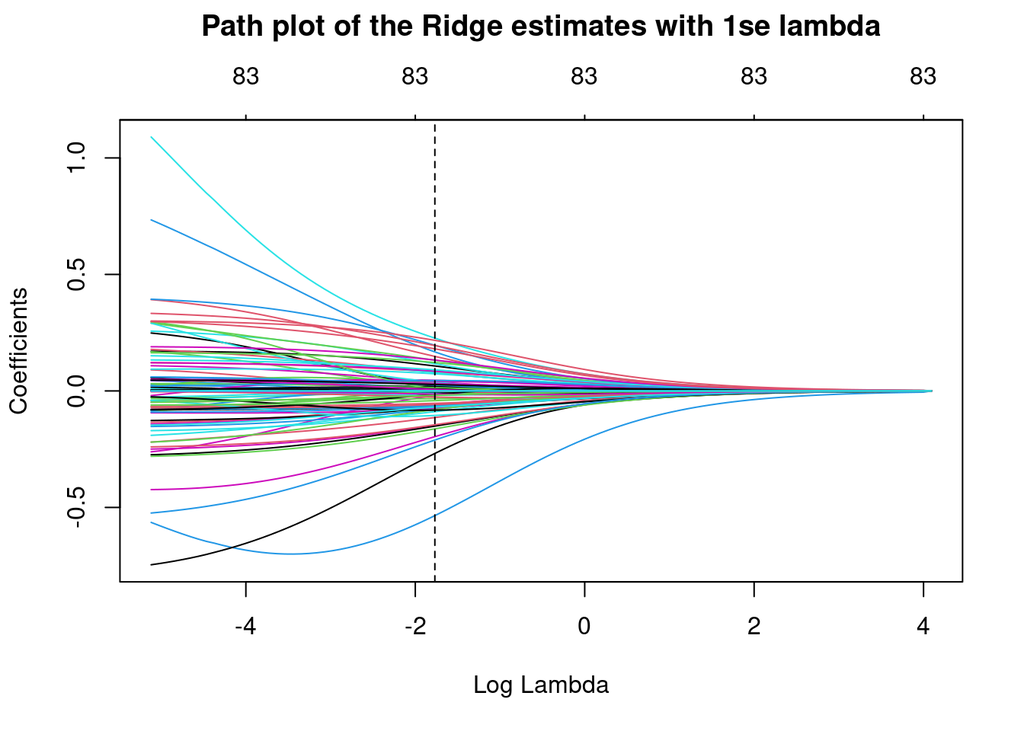

```r
plot(ridge.mod, xvar = "lambda", main='Path plot of the Ridge estimates with 1se lambda\n\n')
abline(v =log(ridge.cv$lambda.1se), lty="dashed")
```

```r
ridge.1se.coef <- coef(ridge.mod,  s=ridge.cv$lambda.1se)
ridge.1se.coef
```

```
## 84 x 1 sparse Matrix of class "dgCMatrix"
##                                                s1
## (Intercept)                          1.128493e+02
## day_periodEarlyMorning               1.070657e-01
## day_periodMorning                    1.481961e-01
## day_periodEarlyAfternoon             2.096669e-02
## day_periodAfternoon                  1.398412e-02
## day_periodEvening                    4.994134e-03
## day_periodNight                     -5.988198e-02
## day_year                            -2.749520e-05
## year                                -1.890901e-02
## week_dayMonday                       1.482545e-03
## week_dayTuesday                     -1.010205e-02
## week_dayWednesday                    1.165909e-01
## week_dayThursday                     3.931904e-02
## week_dayFriday                      -6.069633e-03
## week_daySaturday                    -6.056835e-02
## week_daySunday                      -1.743139e-02
## COVID_lockdownFALSE                  1.046805e-02
## COVID_lockdownTRUE                  -1.046523e-02
## COVID_pandemicFALSE                 -1.990941e-02
## COVID_pandemicTRUE                   1.990736e-02
## working_hourFALSE                   -6.078288e-04
## working_hourTRUE                     5.977159e-04
## Latitude                            -5.351346e-01
## Longitude                            2.265386e-01
## city_locationS_Manhattan            -1.962717e-01
## city_locationN_Manhattan            -7.407719e-02
## city_locationW_Bronx                -1.142091e-01
## city_locationE_Bronx                 3.262457e-02
## city_locationN_E_Queens              7.982813e-03
## city_locationN_W_Queens             -7.244052e-02
## city_locationS_Queens                4.563054e-02
## city_locationN_Brooklyn              1.845153e-02
## city_locationS_E_Brooklyn            7.991153e-02
## city_locationS_W_Brooklyn            1.317041e-01
## city_locationW_Staten_Island         1.674937e-01
## city_locationE_Staten_Island         3.820345e-02
## vic_age<18                          -1.485204e-01
## vic_age18-24                        -6.442542e-02
```

[output cut: 31 more lines]

```
## vic_age<18:vic_raceBLACK            -1.627139e-01
## vic_age18-24:vic_raceBLACK          -6.641096e-02
## vic_age25-44:vic_raceBLACK           9.048907e-02
## vic_age45+:vic_raceBLACK             1.324912e-01
## vic_age<18:vic_raceBLACK HISPANIC   -8.253856e-02
## vic_age18-24:vic_raceBLACK HISPANIC -2.628712e-02
## vic_age25-44:vic_raceBLACK HISPANIC -4.167397e-02
## vic_age45+:vic_raceBLACK HISPANIC   -2.107734e-01
## vic_age<18:vic_raceWHITE HISPANIC   -6.949604e-02
## vic_age18-24:vic_raceWHITE HISPANIC -1.359421e-02
## vic_age25-44:vic_raceWHITE HISPANIC  2.746022e-02
## vic_age45+:vic_raceWHITE HISPANIC    1.805986e-01
## year                                -1.890630e-02
## day_year                            -2.747694e-05
## year:day_year                       -1.523994e-08
```

Differently from Lasso, ridge doesn’t force to zero the coefficient thus is difficult to interpret those numbers.

#### 4.3.3.2 min lambda

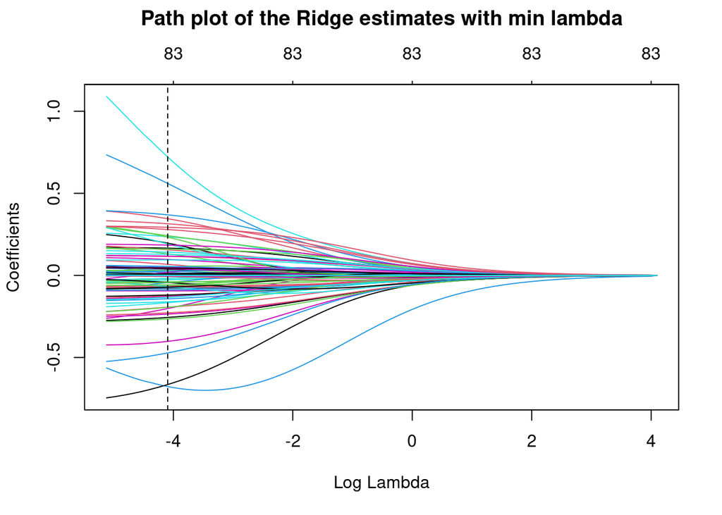

```r
plot(ridge.mod, xvar = "lambda", main='Path plot of the Ridge estimates with min lambda\n\n')
abline(v =log(ridge.cv$lambda.min), lty="dashed")
```

```r
ridge.min.coef <- coef(ridge.mod,  s=ridge.cv$lambda.min)
ridge.min.coef
```

```
## 84 x 1 sparse Matrix of class "dgCMatrix"
##                                                s1
## (Intercept)                          2.514192e+02
## day_periodEarlyMorning               1.660059e-01
## day_periodMorning                    3.453895e-01
## day_periodEarlyAfternoon             1.315331e-01
## day_periodAfternoon                  5.037032e-02
## day_periodEvening                   -1.755234e-02
## day_periodNight                     -1.285347e-01
## day_year                            -9.609862e-05
## year                                -4.271245e-02
## week_dayMonday                      -2.590718e-02
## week_dayTuesday                      1.780817e-02
## week_dayWednesday                    2.358281e-01
## week_dayThursday                     9.737229e-02
## week_dayFriday                       9.690277e-03
## week_daySaturday                    -1.229176e-01
## week_daySunday                      -5.792215e-02
## COVID_lockdownFALSE                  2.912224e-02
## COVID_lockdownTRUE                  -2.694911e-02
## COVID_pandemicFALSE                 -2.018353e-01
## COVID_pandemicTRUE                   1.964097e-01
## working_hourFALSE                    6.753205e-02
## working_hourTRUE                    -6.535565e-02
## Latitude                            -6.770817e-01
## Longitude                            7.215332e-01
## city_locationS_Manhattan            -4.018128e-01
## city_locationN_Manhattan            -1.197395e-01
## city_locationW_Bronx                -1.937954e-01
## city_locationE_Bronx                 5.065655e-02
## city_locationN_E_Queens             -4.391250e-02
## city_locationN_W_Queens             -1.662533e-01
## city_locationS_Queens                1.851096e-02
## city_locationN_Brooklyn              3.769943e-02
## city_locationS_E_Brooklyn            1.561117e-01
## city_locationS_W_Brooklyn            2.419765e-01
## city_locationW_Staten_Island         5.601550e-01
## city_locationE_Staten_Island         1.916206e-01
## vic_age<18                          -2.356224e-01
## vic_age18-24                        -7.920444e-02
```

[output cut: 31 more lines]

```
## vic_age<18:vic_raceBLACK            -2.652221e-01
## vic_age18-24:vic_raceBLACK          -8.878984e-02
## vic_age25-44:vic_raceBLACK           1.279232e-01
## vic_age45+:vic_raceBLACK             1.848001e-01
## vic_age<18:vic_raceBLACK HISPANIC   -4.321822e-02
## vic_age18-24:vic_raceBLACK HISPANIC -6.777094e-03
## vic_age25-44:vic_raceBLACK HISPANIC -5.822450e-02
## vic_age45+:vic_raceBLACK HISPANIC   -4.722695e-01
## vic_age<18:vic_raceWHITE HISPANIC   -1.335779e-01
## vic_age18-24:vic_raceWHITE HISPANIC -2.679587e-03
## vic_age25-44:vic_raceWHITE HISPANIC  4.465847e-02
## vic_age45+:vic_raceWHITE HISPANIC    2.794728e-01
## year                                -4.293775e-02
## day_year                            -9.896524e-05
## year:day_year                       -4.651757e-08
```

#### 4.3.3.3 Model comparison

```r
ridge.1se.pred <- predict(ridge.mod, s=ridge.cv$lambda.1se, newdata = shootings.test, type = "response")
ridge.min.pred <- predict(ridge.mod, s=ridge.cv$lambda.min, newdata = shootings.test, type = "response")
```

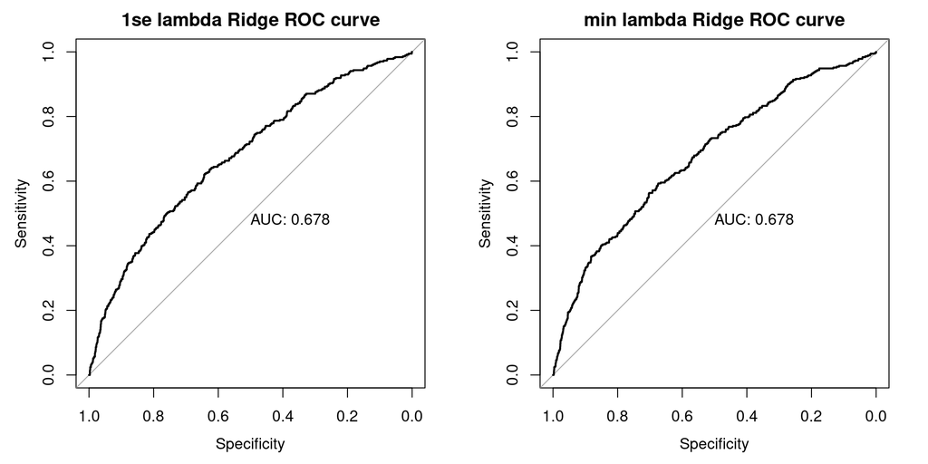

```r
par(mfrow=c(1,2))

ridge.1se.roc <- roc(shootings.test$murder_prob ~ ridge.1se.pred, plot=TRUE, print.auc=TRUE, main="1se lambda Ridge ROC curve")
ridge.min.roc <- roc(shootings.test$murder_prob ~ ridge.min.pred, plot=TRUE, print.auc=TRUE, main="min lambda Ridge ROC curve")
```

```r
ridge.1se.metrics <- coords(ridge.1se.roc, x="best", ret="all")
row.names(ridge.1se.metrics) <- "ridge 1se lambda"

ridge.min.metrics <- coords(ridge.min.roc, x="best", ret="all")
row.names(ridge.min.metrics) <- "ridge min lambda"
```

```r
metrics <- rbind(metrics, ridge.1se.metrics, ridge.min.metrics)
```

```r
(metrics %>% arrange(desc(sensitivity)))[, c("specificity", "sensitivity", "accuracy")]
```

```
##                                               specificity sensitivity  accuracy
## ridge 1se lambda                                0.6416185   0.6226415 0.6385224
## Lasso min lambda                                0.6684183   0.6010782 0.6574318
## ridge min lambda                                0.6741986   0.5929919 0.6609499
## Lasso 1se lambda                                0.6915397   0.5633423 0.6706245
## Full model                                      0.7724645   0.5067385 0.7291117
## Significant predictors model with interaction   0.7961114   0.5013477 0.7480211
## Significant predictors model                    0.8187073   0.4851752 0.7642920
## Full model with interaction                     0.8602207   0.4123989 0.7871592
## Step model                                      0.8539149   0.4123989 0.7818821
```

Ridge 1se lambda model is the best in terms of sensitivity. Ridge min lambda is above average in terms of sensitivity. Thus the best overall model is Ridge 1se lambda.

Confusion Matrix for `lambda.1se`:

```r
confusion_matrix(ridge.1se.pred, ridge.1se.metrics$threshold)
```

```
##        true
## preds   FALSE TRUE
##   FALSE  1221  140
##   TRUE    682  231
```

Confusion Matrix for `lambda.min`:

```r
confusion_matrix(ridge.min.pred, ridge.min.metrics$threshold)
```

```
##        true
## preds   FALSE TRUE
##   FALSE  1283  151
##   TRUE    620  220
```

# 5 Naive Bayes

```r
nb.fit <- naiveBayes(formula(glm.full), data = shootings.train)
nb.fit
```

```
##
## Naive Bayes Classifier for Discrete Predictors
##
## Call:
## naiveBayes.default(x = X, y = Y, laplace = laplace)
##
## A-priori probabilities:
## Y
##         0         1
## 0.8333883 0.1666117
##
## Conditional probabilities:
##    day_period
## Y   EarlyMorning    Morning EarlyAfternoon  Afternoon    Evening      Night
##   0   0.05199261 0.03655318     0.06004223 0.14858802 0.21786751 0.48495645
##   1   0.07062706 0.05148515     0.06138614 0.14983498 0.21980198 0.44686469
##
##    day_year
## Y       [,1]     [,2]
##   0 199.2666 92.95983
##   1 199.3505 97.70213
##
##    year
## Y       [,1]     [,2]
##   0 2014.518 4.756775
##   1 2013.360 5.109580
##
##    week_day
## Y       Monday    Tuesday  Wednesday   Thursday     Friday   Saturday
##   0 0.14740037 0.10649248 0.09474795 0.10345738 0.12747427 0.20374769
##   1 0.15313531 0.10099010 0.11947195 0.11023102 0.12409241 0.17887789
##    week_day
## Y       Sunday
##   0 0.21667986
##   1 0.21320132
##
##    COVID_lockdown
## Y        FALSE       TRUE
##   0 0.93190816 0.06809184
##   1 0.94257426 0.05742574
```

[output cut: 30 more lines]

```
##
##    vic_race
## Y   ASIAN/WHITE      BLACK BLACK HISPANIC WHITE HISPANIC
##   0  0.02454473 0.76616522     0.09144893     0.11784112
##   1  0.03168317 0.78745875     0.06666667     0.11419142
##
##    other_victims
## Y        [,1]      [,2]
##   0 0.3401953 0.8693888
##   1 0.7821782 1.5377502
##
##    jurisdiction
## Y      PATROL   HOUSING
##   0 0.8171021 0.1828979
##   1 0.8587459 0.1412541
```

```r
nb.pred <- predict(nb.fit, newdata = shootings.test, type = "raw")
```

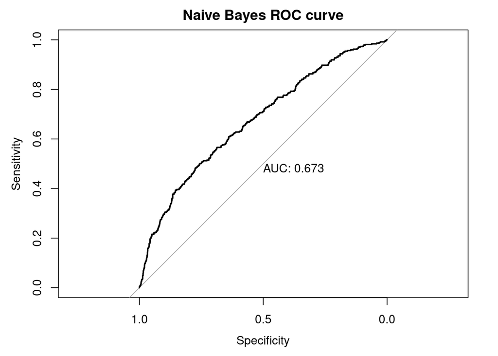

```r
nb.roc <- roc(shootings.test$murder_prob ~ nb.pred[,2], plot=TRUE, print.auc=TRUE, main="Naive Bayes ROC curve")
```

```r
nb.metrics <- coords(nb.roc, x="best", ret="all")
row.names(nb.metrics) <- "Naive bayes"
```

```r
metrics <- rbind(metrics, nb.metrics)
```

```r
(metrics %>% arrange(desc(sensitivity)))[, c("specificity", "sensitivity", "accuracy")]
```

```
##                                               specificity sensitivity  accuracy
## ridge 1se lambda                                0.6416185   0.6226415 0.6385224
## Lasso min lambda                                0.6684183   0.6010782 0.6574318
## ridge min lambda                                0.6741986   0.5929919 0.6609499
## Lasso 1se lambda                                0.6915397   0.5633423 0.6706245
## Full model                                      0.7724645   0.5067385 0.7291117
## Significant predictors model with interaction   0.7961114   0.5013477 0.7480211
## Significant predictors model                    0.8187073   0.4851752 0.7642920
## Naive bayes                                     0.7745665   0.4824798 0.7269129
## Full model with interaction                     0.8602207   0.4123989 0.7871592
## Step model                                      0.8539149   0.4123989 0.7818821
```

Naive Bayes is below average in terms of sensitivity.

Confusion matrix for Naive Bayes:

```r
confusion_matrix(nb.pred[,2], nb.metrics$threshold)
```

```
##        true
## preds   FALSE TRUE
##   FALSE  1474  192
##   TRUE    429  179
```

# 6 GAM

Now let’s fit a GAM model with all predictors (interaction term included). I applied splines to all the numerical predictors.

```r
f <- update(formula(glm.full.inter), . ~ . -Latitude -Longitude -day_year -year -year:day_year + s(year) + s(day_year, bs="cc")+ s(Latitude) + s(Longitude))
gam.fit <- gam(f, data=shootings.train, family=binomial)

summary(gam.fit)
```

```
##
## Family: binomial
## Link function: logit
##
## Formula:
## murder_prob ~ day_period + week_day + COVID_lockdown + COVID_pandemic +
##     working_hour + vic_age + vic_sex + vic_race + other_victims +
##     jurisdiction + s(year) + s(day_year, bs = "cc") + s(Latitude) +
##     s(Longitude)
##
## Parametric coefficients:
##                           Estimate Std. Error z value Pr(>|z|)
## (Intercept)              -3.162071   0.287624 -10.994  < 2e-16 ***
## day_periodMorning         0.233674   0.200703   1.164   0.2443
## day_periodEarlyAfternoon  0.018120   0.187906   0.096   0.9232
## day_periodAfternoon      -0.118326   0.141857  -0.834   0.4042
## day_periodEvening        -0.212320   0.132629  -1.601   0.1094
## day_periodNight          -0.298720   0.122964  -2.429   0.0151 *
## week_dayTuesday           0.069072   0.119255   0.579   0.5625
## week_dayWednesday         0.292457   0.115805   2.525   0.0116 *
## week_dayThursday          0.149790   0.116720   1.283   0.1994
## week_dayFriday            0.037352   0.112749   0.331   0.7404
## week_daySaturday         -0.106429   0.105086  -1.013   0.3112
## week_daySunday           -0.049288   0.102667  -0.480   0.6312
## COVID_lockdownTRUE       -0.004743   0.180931  -0.026   0.9791
## COVID_pandemicTRUE        0.275727   0.261771   1.053   0.2922
## working_hourTRUE         -0.208859   0.136606  -1.529   0.1263
## vic_age18-24              0.536828   0.133268   4.028 5.62e-05 ***
## vic_age25-44              1.107160   0.130560   8.480  < 2e-16 ***
## vic_age45+                1.340310   0.160588   8.346  < 2e-16 ***
## vic_sexM                  0.707178   0.128542   5.502 3.77e-08 ***
## vic_raceBLACK            -0.046345   0.176001  -0.263   0.7923
## vic_raceBLACK HISPANIC   -0.323913   0.206869  -1.566   0.1174
## vic_raceWHITE HISPANIC   -0.047468   0.194772  -0.244   0.8075
## other_victims             0.414998   0.025034  16.577  < 2e-16 ***
## jurisdictionHOUSING      -0.162426   0.084194  -1.929   0.0537 .
## ---
## Signif. codes:  0 '***' 0.001 '**' 0.01 '*' 0.05 '.' 0.1 ' ' 1
##
## Approximate significance of smooth terms:
##                edf Ref.df  Chi.sq  p-value
## s(year)      4.826  5.931 148.674  < 2e-16 ***
## s(day_year)  2.450  8.000  13.838 0.000507 ***
## s(Latitude)  3.340  4.160  33.373  1.1e-06 ***
## s(Longitude) 1.005  1.009   2.088 0.150466
## ---
## Signif. codes:  0 '***' 0.001 '**' 0.01 '*' 0.05 '.' 0.1 ' ' 1
##
## R-sq.(adj) =  0.0739   Deviance explained = 7.98%
## UBRE = -0.16307  Scale est. = 1         n = 9093
```

Plot of the splines effect:

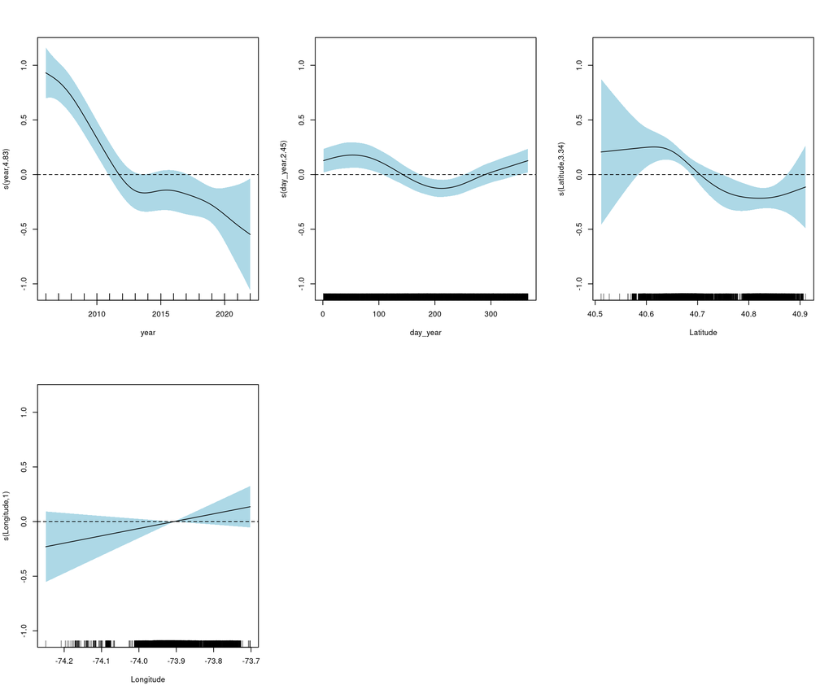

```r
par(mfrow=c(2,3))

for (i in 1:5){
  plot(gam.fit, select=i, shade=TRUE, shade.col = "lightblue")
  abline(h=0, lty="dashed")
}
```

As we can see both for the model summary and the plots the effect of Longitude seams linear; day of the year seams periodic and year and Latitude highly non linear.

Now let’s try fitting a GAM model now with only significant predictors:

```r
gam2.fit <- update(gam.fit, . ~ . -s(Longitude) +Longitude -COVID_lockdown -COVID_pandemic -working_hour -vic_race)

summary(gam2.fit)
```

```
##
## Family: binomial
## Link function: logit
##
## Formula:
## murder_prob ~ day_period + week_day + vic_age + vic_sex + other_victims +
##     jurisdiction + s(year) + s(day_year, bs = "cc") + s(Latitude) +
##     Longitude
##
## Parametric coefficients:
##                          Estimate Std. Error z value Pr(>|z|)
## (Intercept)              46.81390   34.21976   1.368   0.1713
## day_periodMorning         0.09685    0.17737   0.546   0.5850
## day_periodEarlyAfternoon -0.11295    0.16574  -0.681   0.4956
## day_periodAfternoon      -0.15620    0.13901  -1.124   0.2612
## day_periodEvening        -0.19890    0.13237  -1.503   0.1329
## day_periodNight          -0.29117    0.12287  -2.370   0.0178 *
## week_dayTuesday           0.07304    0.11913   0.613   0.5398
## week_dayWednesday         0.29724    0.11564   2.570   0.0102 *
## week_dayThursday          0.15486    0.11660   1.328   0.1841
## week_dayFriday            0.04371    0.11263   0.388   0.6979
## week_daySaturday         -0.07493    0.10318  -0.726   0.4677
## week_daySunday           -0.01811    0.10032  -0.180   0.8568
## vic_age18-24              0.53413    0.13313   4.012 6.02e-05 ***
## vic_age25-44              1.10441    0.13039   8.470  < 2e-16 ***
## vic_age45+                1.34010    0.15976   8.388  < 2e-16 ***
## vic_sexM                  0.70788    0.12842   5.512 3.55e-08 ***
## other_victims             0.41159    0.02494  16.501  < 2e-16 ***
## jurisdictionHOUSING      -0.15886    0.08398  -1.892   0.0585 .
## Longitude                 0.67654    0.46299   1.461   0.1439
## ---
## Signif. codes:  0 '***' 0.001 '**' 0.01 '*' 0.05 '.' 0.1 ' ' 1
##
## Approximate significance of smooth terms:
##               edf Ref.df Chi.sq  p-value
## s(year)     4.694  5.748 175.73  < 2e-16 ***
## s(day_year) 2.366  8.000  12.62 0.000915 ***
## s(Latitude) 3.484  4.334  42.63  < 2e-16 ***
## ---
## Signif. codes:  0 '***' 0.001 '**' 0.01 '*' 0.05 '.' 0.1 ' ' 1
##
## R-sq.(adj) =  0.0732   Deviance explained = 7.84%
## UBRE = -0.16322  Scale est. = 1         n = 9093
```

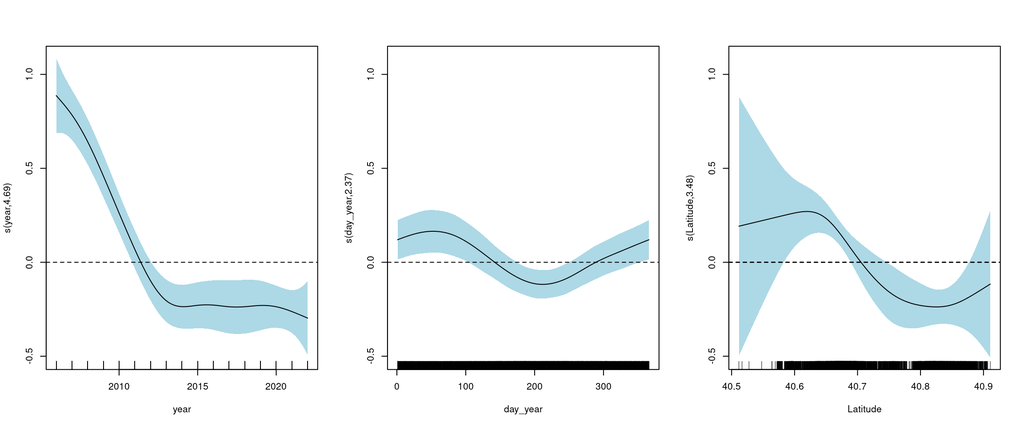

```r
par(mfrow=c(1,3))

for (i in 1:5){
  plot(gam2.fit, select=i, shade=TRUE, shade.col = "lightblue")
  abline(h=0, lty="dashed")
}
```

The splines effects doesn’t change much compared to the previews model.

## 6.1 Model comparison

```r
gam.predict <- predict(gam.fit, newdata = shootings.test, type = "response")
gam2.predict <- predict(gam2.fit, newdata = shootings.test, type = "response")
```

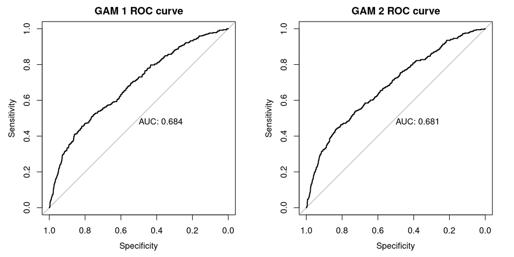

```r
par(mfrow=c(1,2))

gam.roc <- roc(shootings.test$murder_prob ~ gam.predict, plot=TRUE, print.auc=TRUE, main="GAM 1 ROC curve")
gam2.roc <- roc(shootings.test$murder_prob ~ gam2.predict, plot=TRUE, print.auc=TRUE, main="GAM 2 ROC curve")
```

The ROC curves are quite similar.

```r
gam.metrics <- coords(gam.roc, x="best", ret="all")
gam2.metrics <- coords(gam2.roc, x="best", ret="all")

row.names(gam.metrics) <- "GAM1"
row.names(gam2.metrics) <- "GAM2"
```

```r
metrics <- rbind(metrics, gam.metrics, gam2.metrics)
```

```r
(metrics %>% arrange(desc(sensitivity)))[, c("specificity", "sensitivity", "accuracy")]
```

```
##                                               specificity sensitivity  accuracy
## ridge 1se lambda                                0.6416185   0.6226415 0.6385224
## Lasso min lambda                                0.6684183   0.6010782 0.6574318
## ridge min lambda                                0.6741986   0.5929919 0.6609499
## Lasso 1se lambda                                0.6915397   0.5633423 0.6706245
## Full model                                      0.7724645   0.5067385 0.7291117
## Significant predictors model with interaction   0.7961114   0.5013477 0.7480211
## Significant predictors model                    0.8187073   0.4851752 0.7642920
## Naive bayes                                     0.7745665   0.4824798 0.7269129
## GAM1                                            0.8176563   0.4555256 0.7585752
## GAM2                                            0.8334209   0.4393531 0.7691293
## Full model with interaction                     0.8602207   0.4123989 0.7871592
## Step model                                      0.8539149   0.4123989 0.7818821
```